# F0 CRISPR Screen: Adipose Morphology Analysis

KS Tests and Linear Mixed Models with Batch Correction

Minchin Lab

2026-01-29

# Overview

This document presents two complementary statistical approaches to analyse adipose tissue morphology phenotypes from an F0 CRISPR screen:

1. **Kolmogorov-Smirnov (KS) tests** comparing residual distributions
2. **Linear Mixed Models (LMM)** with experiment as random effect

Both approaches account for batch effects between experiments and apply Benjamini-Hochberg correction for multiple testing.

We also test whether mutants show altered/unequal variance and verify LMM results using alternative methods that do not assume equal variance.

**Note:** Genes *aspa* and *lamb2* had only one experiment each and are analysed separately using standard linear models (Analysis 3).

# Setup

```r
library(mgcv)
library(lme4)
library(lmerTest)
library(nlme)       # For heteroscedastic LMM
library(knitr)
library(kableExtra)

# Optional: moments package for skewness/kurtosis
# install.packages("moments") if not installed
if (!require(moments, quietly = TRUE)) {
  message("Package 'moments' not installed - skewness/kurtosis will be NA")
}
```

```r
# SET YOUR DATA FILE PATH HERE
data_file <- "F0_CRISPR_screen_data_merged.csv"

# Load the merged data
all_data <- read.csv(data_file, stringsAsFactors = FALSE)

# Genes to EXCLUDE from main analysis (only 1 experiment - no batch correction possible)
single_expt_genes <- c("aspa", "lamb2")

# Standardise experiment names
standardise_exp_name <- function(exp_name) {
  exp_name <- tolower(trimws(exp_name))
  exp_name <- gsub("^exp([0-9]+)$", "expt\\1", exp_name)
  return(exp_name)
}

all_data$experiment <- sapply(all_data$experiment, standardise_exp_name)

# Get list of all genes
all_genes <- unique(all_data$gene)

# Identify genes with multiple experiments
genes_multi_expt <- c()
for (g in all_genes) {
  gene_data <- all_data[all_data$gene == g, ]
  n_expts <- length(unique(gene_data$experiment))
  if (n_expts >= 2) {
    genes_multi_expt <- c(genes_multi_expt, g)
  }
}

# Genes for main analysis (multi-experiment)
gene_names <- setdiff(genes_multi_expt, single_expt_genes)

cat("Data file:", data_file, "\n")
```

```
## Data file: F0_CRISPR_screen_data_merged.csv
```

```r
cat("Total observations:", nrow(all_data), "\n")
```

```
## Total observations: 1394
```

```r
cat("Total genes:", length(all_genes), "\n")
```

```
## Total genes: 23
```

```r
cat("Genes with multiple experiments:", length(genes_multi_expt), "\n")
```

```
## Genes with multiple experiments: 21
```

```r
cat("Genes excluded (single experiment):", paste(single_expt_genes, collapse = ", "), "\n")
```

```
## Genes excluded (single experiment): aspa, lamb2
```

```r
cat("Genes in main analysis:", length(gene_names), "\n")
```

```
## Genes in main analysis: 21
```

```r
# Function to format gene name (italicized for markdown)
format_gene_name <- function(gene, italics = TRUE) {
  if (italics) return(paste0("*", gene, "*"))
  return(gene)
}

# Calculate statistical power for two-sample t-test
calc_power <- function(n1, n2, d, alpha = 0.05) {
  n_harmonic <- 2 / (1/n1 + 1/n2)
  ncp <- d * sqrt(n_harmonic / 2)
  df <- n1 + n2 - 2
  t_crit <- qt(1 - alpha/2, df)
  power <- 1 - pt(t_crit, df, ncp) + pt(-t_crit, df, ncp)
  return(round(power * 100, 0))
}
```

# Analysis 1: KS Tests with Experiment-Specific Controls

## Methods

For each gene:

1. Pool control and experimental data from all experiments
2. Fit GAM to controls: `Feret ~ s(log(AreaSum))`
3. Calculate residuals for controls (baseline distribution)
4. Calculate deviations for experimental fish from the control GAM
5. Compare distributions using two-sample Kolmogorov-Smirnov test
6. Apply Benjamini-Hochberg correction across all tests

**Morphology value** = deviation from expected Feret diameter given total adipose area

- Positive values → Hypertrophic (larger droplets than expected)
- Negative values → Hyperplastic (smaller droplets than expected)

## Run KS Tests

```r
ks_results_list <- list()

for (gene in gene_names) {

  ctrl_data <- all_data[all_data$gene == gene & all_data$genotype == "control", ]
  expt_data <- all_data[all_data$gene == gene & all_data$genotype == "mutant", ]

  # Clean data

  ctrl_data <- ctrl_data[!is.na(ctrl_data$AreaSum) & ctrl_data$AreaSum > 0 &
                         !is.na(ctrl_data$Feret), ]
  expt_data <- expt_data[!is.na(expt_data$AreaSum) & expt_data$AreaSum > 0 &
                         !is.na(expt_data$Feret), ]

  if (nrow(ctrl_data) < 5 || nrow(expt_data) < 5) next

  # Fit GAM to controls
  gam_model <- gam(Feret ~ s(log(AreaSum)), data = ctrl_data)
  ctrl_residuals <- residuals(gam_model)

  # Calculate deviations for experimental
  pred <- predict(gam_model, newdata = data.frame(AreaSum = expt_data$AreaSum))
  expt_deviations <- expt_data$Feret - pred

  # KS test
  ks_result <- ks.test(ctrl_residuals, expt_deviations)

  ks_results_list[[gene]] <- data.frame(
    gene = gene,
    n_ctrl = nrow(ctrl_data),
    n_expt = nrow(expt_data),
    effect_um = round(mean(expt_deviations), 2),
    KS_D = round(ks_result$statistic, 3),
    KS_p = ks_result$p.value,
    stringsAsFactors = FALSE
  )
}

ks_results <- do.call(rbind, ks_results_list)
rownames(ks_results) <- NULL

# BH correction
ks_results$KS_p_adj <- p.adjust(ks_results$KS_p, method = "BH")
ks_results$KS_sig <- ks_results$KS_p_adj < 0.05
ks_results$direction <- ifelse(ks_results$effect_um > 0, "Hypertrophic", "Hyperplastic")

# Sort by p-value
ks_results <- ks_results[order(ks_results$KS_p), ]
```

## KS Test Results

```r
# Add formatted gene names
ks_results$gene_md <- sapply(ks_results$gene, function(x) format_gene_name(x, italics = TRUE))

# Track significance levels
ks_results$raw_sig <- ks_results$KS_p < 0.05
ks_results$raw_only_sig <- ks_results$raw_sig & !ks_results$KS_sig  # raw sig but not after BH

# Count experiments per gene
ks_results$n_expts <- sapply(ks_results$gene, function(g) {
  length(unique(all_data$experiment[all_data$gene == g]))
})

ks_display <- data.frame(
  Gene = ks_results$gene_md,
  n_expts = ks_results$n_expts,
  n_ctrl = ks_results$n_ctrl,
  n_expt = ks_results$n_expt,
  Effect_um = sprintf("%+.2f", ks_results$effect_um),
  Direction = ks_results$direction,
  p_raw = ifelse(ks_results$KS_p < 0.001, sprintf("%.2e", ks_results$KS_p), sprintf("%.4f", ks_results$KS_p)),
  p_adj = ifelse(ks_results$KS_p_adj < 0.001, sprintf("%.2e", ks_results$KS_p_adj), sprintf("%.4f", ks_results$KS_p_adj)),
  Sig = ifelse(ks_results$KS_sig, "***", ifelse(ks_results$raw_only_sig, "*", ""))
)

kable(ks_display,
      col.names = c("Gene", "Expts", "n (ctrl)", "n (mut)", "Effect (um)", "Direction", "p (raw)", "p (adj)", "Sig."),
      caption = "KS Test Results: Adipose morphology phenotypes (*** = BH-adjusted p < 0.05; * = raw p < 0.05 only)",
      align = c("l", "c", "c", "c", "r", "l", "r", "r", "c")) %>%
  kable_styling(bootstrap_options = c("striped", "hover", "condensed"), full_width = FALSE) %>%
  row_spec(which(ks_results$KS_sig), bold = TRUE, background = "#d4edda") %>%  # Green for BH-significant
  row_spec(which(ks_results$raw_only_sig), bold = FALSE, background = "#fff3cd")  # Yellow for raw-only
```

KS Test Results: Adipose morphology phenotypes (*** = BH-adjusted p < 0.05; * = raw p < 0.05 only)

Gene

Expts

n (ctrl)

n (mut)

Effect (um)

Direction

p (raw)

p (adj)

Sig.

*mmp14b*

2

34

30

+5.44

Hypertrophic

8.50e-05

0.0018

***

*ptenb*

2

27

25

-4.66

Hyperplastic

0.0051

0.0539

*foxp1b*

2

42

45

+8.84

Hypertrophic

0.0091

0.0638

*txnipa*

3

45

30

+4.61

Hypertrophic

0.0127

0.0664

*ptprdb*

2

35

24

+4.00

Hypertrophic

0.0190

0.0796

*srpx*

2

36

20

-5.72

Hyperplastic

0.0441

0.1545

*prrx1b*

3

65

60

-3.50

Hyperplastic

0.0592

0.1775

*nav3*

3

49

42

-2.39

Hyperplastic

0.0737

0.1935

*ptprga*

2

35

35

-1.42

Hyperplastic

0.1151

0.2685

*sparc*

2

24

23

-2.14

Hyperplastic

0.1361

0.2858

*tmem115*

2

27

29

-3.11

Hyperplastic

0.2556

0.4880

*cxcl14*

2

27

24

-4.37

Hyperplastic

0.2981

0.5217

*lrmda*

2

27

22

-0.39

Hyperplastic

0.3263

0.5271

*cacnb4a*

2

29

27

+0.94

Hypertrophic

0.5159

0.7057

*runx1t1*

2

29

22

+1.09

Hypertrophic

0.5409

0.7057

*kazna*

2

36

23

-3.09

Hyperplastic

0.5524

0.7057

*tbx15*

3

37

26

+3.38

Hypertrophic

0.5712

0.7057

*cd81a*

2

24

26

+0.03

Hypertrophic

0.7390

0.8622

*sdk1a*

2

29

25

+0.62

Hypertrophic

0.7907

0.8694

*pard3ab*

2

36

32

-1.48

Hyperplastic

0.8434

0.8694

*pid1*

2

27

26

-2.68

Hyperplastic

0.8694

0.8694

```r
ks_bh_sig <- ks_results[ks_results$KS_sig, ]
ks_raw_only <- ks_results[ks_results$raw_only_sig, ]

cat("**Significant after BH correction (p_adj < 0.05):**\n\n")
```

**Significant after BH correction (p_adj < 0.05):**

```r
if (nrow(ks_bh_sig) > 0) {
  for (i in 1:nrow(ks_bh_sig)) {
    cat(sprintf("- **%s**: %s (%+.1f um, adj.p = %.4f)\n",
                ks_bh_sig$gene_md[i], ks_bh_sig$direction[i], ks_bh_sig$effect_um[i], ks_bh_sig$KS_p_adj[i]))
  }
} else {
  cat("None\n")
}
```

- *mmp14b*: Hypertrophic (+5.4 um, adj.p = 0.0018)

```r
cat("\n**Nominally significant only (raw p < 0.05, not significant after BH):**\n\n")
```

**Nominally significant only (raw p < 0.05, not significant after BH):**

```r
if (nrow(ks_raw_only) > 0) {
  for (i in 1:nrow(ks_raw_only)) {
    cat(sprintf("- %s: %s (%+.1f um, raw p = %.4f, adj.p = %.4f)\n",
                ks_raw_only$gene_md[i], ks_raw_only$direction[i], ks_raw_only$effect_um[i],
                ks_raw_only$KS_p[i], ks_raw_only$KS_p_adj[i]))
  }
} else {
  cat("None\n")
}
```

- *ptenb*: Hyperplastic (-4.7 um, raw p = 0.0051, adj.p = 0.0539)
- *foxp1b*: Hypertrophic (+8.8 um, raw p = 0.0091, adj.p = 0.0638)
- *txnipa*: Hypertrophic (+4.6 um, raw p = 0.0127, adj.p = 0.0664)
- *ptprdb*: Hypertrophic (+4.0 um, raw p = 0.0190, adj.p = 0.0796)
- *srpx*: Hyperplastic (-5.7 um, raw p = 0.0441, adj.p = 0.1545)

## Stratified KS Validation (Within-Experiment Analysis)

The pooled KS test combines data across experiments, which could be inflated by batch effects if mutants and controls are not balanced across experiments. To validate, we run KS tests **separately within each experiment** and combine p-values using Fisher’s method.

```r
# Run stratified KS tests (within each experiment)
stratified_results <- list()

for (gene in gene_names) {

  ctrl_data <- all_data[all_data$gene == gene & all_data$genotype == "control", ]
  expt_data <- all_data[all_data$gene == gene & all_data$genotype == "mutant", ]

  # Clean data
  ctrl_data <- ctrl_data[!is.na(ctrl_data$AreaSum) & ctrl_data$AreaSum > 0 &
                         !is.na(ctrl_data$Feret) & ctrl_data$Feret > 0, ]
  expt_data <- expt_data[!is.na(expt_data$AreaSum) & expt_data$AreaSum > 0 &
                         !is.na(expt_data$Feret) & expt_data$Feret > 0, ]

  if (nrow(ctrl_data) < 5 | nrow(expt_data) < 5) next

  # Get shared experiments
  shared_expts <- intersect(unique(ctrl_data$experiment), unique(expt_data$experiment))

  if (length(shared_expts) < 2) next  # Need at least 2 experiments for stratified analysis

  # Run KS test within each experiment
  expt_p_values <- numeric()
  expt_effects <- numeric()
  expt_n <- numeric()

  for (exp in shared_expts) {
    ctrl_exp <- ctrl_data[ctrl_data$experiment == exp, ]
    expt_exp <- expt_data[expt_data$experiment == exp, ]

    if (nrow(ctrl_exp) < 3 | nrow(expt_exp) < 3) next

    # Fit GAM to controls within this experiment
    gam_exp <- tryCatch({
      gam(Feret ~ s(log(AreaSum)), data = ctrl_exp)
    }, error = function(e) {
      lm(Feret ~ log(AreaSum), data = ctrl_exp)
    })

    ctrl_resid <- residuals(gam_exp)
    expt_pred <- predict(gam_exp, newdata = data.frame(AreaSum = expt_exp$AreaSum))
    expt_dev <- expt_exp$Feret - expt_pred

    # KS test
    ks_exp <- ks.test(expt_dev, ctrl_resid)
    expt_p_values <- c(expt_p_values, ks_exp$p.value)
    expt_effects <- c(expt_effects, mean(expt_dev) - mean(ctrl_resid))
    expt_n <- c(expt_n, nrow(ctrl_exp) + nrow(expt_exp))
  }

  if (length(expt_p_values) < 2) next

  # Combine p-values using Fisher's method
  fisher_stat <- -2 * sum(log(expt_p_values))
  fisher_df <- 2 * length(expt_p_values)
  fisher_p <- pchisq(fisher_stat, df = fisher_df, lower.tail = FALSE)

  # Weighted average effect
  weighted_effect <- sum(expt_effects * expt_n) / sum(expt_n)

  # Get pooled KS result for comparison
  pooled_p <- ks_results$KS_p[ks_results$gene == gene]
  pooled_effect <- ks_results$effect_um[ks_results$gene == gene]

  stratified_results[[gene]] <- data.frame(
    gene = gene,
    n_experiments = length(expt_p_values),
    pooled_p = pooled_p,
    stratified_p = fisher_p,
    pooled_effect = pooled_effect,
    stratified_effect = weighted_effect,
    stringsAsFactors = FALSE
  )
}

stratified_df <- do.call(rbind, stratified_results)
rownames(stratified_df) <- NULL

# BH correction for stratified p-values
stratified_df$stratified_p_adj <- p.adjust(stratified_df$stratified_p, method = "BH")
stratified_df$pooled_sig <- stratified_df$pooled_p < 0.05
stratified_df$stratified_sig <- stratified_df$stratified_p_adj < 0.05

# Determine agreement
stratified_df$agreement <- ifelse(
  stratified_df$pooled_sig & stratified_df$stratified_sig, "Both sig",
  ifelse(!stratified_df$pooled_sig & !stratified_df$stratified_sig, "Both NS",
  ifelse(stratified_df$pooled_sig & !stratified_df$stratified_sig, "Pooled only",
  "Stratified only")))
```

### Pooled vs Stratified KS Comparison

**Note on significance criteria:**

- **Pooled Sig:** Based on raw p-value < 0.05 (NOT BH-adjusted, to allow comparison with stratified)
- **Stratified Sig:** Based on BH-adjusted p-value < 0.05 (Fisher’s combined p-values, then corrected)

```r
# Create display table
stratified_display <- data.frame(
  Gene = sapply(stratified_df$gene, function(x) format_gene_name(x, italics = TRUE)),
  n_expts = stratified_df$n_experiments,
  Pooled_effect = round(stratified_df$pooled_effect, 1),
  Pooled_p_raw = round(stratified_df$pooled_p, 4),
  Pooled_sig = ifelse(stratified_df$pooled_sig, "*", ""),
  Strat_effect = round(stratified_df$stratified_effect, 1),
  Strat_p_adj = round(stratified_df$stratified_p_adj, 4),
  Strat_sig = ifelse(stratified_df$stratified_sig, "***", ""),
  Agreement = stratified_df$agreement,
  stringsAsFactors = FALSE
)

# Sort by pooled p-value
stratified_display <- stratified_display[order(stratified_df$pooled_p), ]

kable(stratified_display, row.names = FALSE,
      col.names = c("Gene", "n Expts", "Effect (um)", "p (raw)", "Sig", "Effect (um)", "p (adj)", "Sig", "Agreement"),
      caption = "Pooled vs Stratified KS Comparison (* = raw p < 0.05; *** = BH-adjusted p < 0.05)") %>%
  kable_styling(bootstrap_options = c("striped", "hover", "condensed"), full_width = FALSE) %>%
  add_header_above(c(" " = 2, "Pooled KS" = 3, "Stratified KS" = 3, " " = 1)) %>%
  row_spec(which(stratified_df$agreement[order(stratified_df$pooled_p)] == "Both sig"), background = "#d4edda") %>%
  row_spec(which(stratified_df$agreement[order(stratified_df$pooled_p)] == "Pooled only"), background = "#fff3cd") %>%
  row_spec(which(stratified_df$agreement[order(stratified_df$pooled_p)] == "Stratified only"), background = "#cce5ff")
```

Pooled vs Stratified KS Comparison (* = raw p < 0.05; *** = BH-adjusted p < 0.05)

Pooled KS

Stratified KS

Gene

n Expts

Effect (um)

p (raw)

Sig

Effect (um)

p (adj)

Sig

Agreement

*mmp14b*

2

5.4

0.0001

5.8

0.0052

***

Both sig

*ptenb*

2

-4.7

0.0051

-3.1

0.0768

Pooled only

*foxp1b*

2

8.8

0.0091

13.6

0.0194

***

Both sig

*txnipa*

3

4.6

0.0127

7.8

0.0001

***

Both sig

*ptprdb*

2

4.0

0.0190

4.9

0.0565

Pooled only

*srpx*

2

-5.7

0.0441

-5.4

0.2039

Pooled only

*prrx1b*

3

-3.5

0.0592

-3.5

0.0768

Both NS

*nav3*

3

-2.4

0.0737

-1.7

0.5624

Both NS

*ptprga*

2

-1.4

0.1151

-1.3

0.0768

Both NS

*sparc*

2

-2.1

0.1361

0.3

0.5532

Both NS

*tmem115*

2

-3.1

0.2556

-2.3

0.0194

***

Stratified only

*cxcl14*

2

-4.4

0.2981

-4.7

0.0768

Both NS

*lrmda*

2

-0.4

0.3263

-0.8

0.0768

Both NS

*cacnb4a*

2

0.9

0.5159

0.6

0.8516

Both NS

*runx1t1*

2

1.1

0.5409

1.5

0.7946

Both NS

*kazna*

2

-3.1

0.5524

-2.1

0.1478

Both NS

*tbx15*

3

3.4

0.5712

6.0

0.0194

***

Stratified only

*cd81a*

2

0.0

0.7390

1.7

0.0642

Both NS

*sdk1a*

2

0.6

0.7907

0.8

0.4816

Both NS

*pard3ab*

2

-1.5

0.8434

-0.7

0.7496

Both NS

*pid1*

2

-2.7

0.8694

-2.3

0.2039

Both NS

```r
both_sig <- stratified_df[stratified_df$agreement == "Both sig", ]
pooled_only <- stratified_df[stratified_df$agreement == "Pooled only", ]
stratified_only <- stratified_df[stratified_df$agreement == "Stratified only", ]

cat("**Interpretation:**\n\n")
```

**Interpretation:**

```r
cat("- **Both sig** (green): Robust signal - pooled raw p < 0.05 AND stratified BH-adjusted p < 0.05\n")
```

- **Both sig** (green): Robust signal - pooled raw p < 0.05 AND stratified BH-adjusted p < 0.05

```r
cat("- **Pooled only** (yellow): Potential batch artifact - pooled raw p < 0.05 but stratified NS after correction\n")
```

- **Pooled only** (yellow): Potential batch artifact - pooled raw p < 0.05 but stratified NS after correction

```r
cat("- **Stratified only** (blue): Stratified BH-adjusted p < 0.05 but pooled raw p ≥ 0.05\n\n")
```

- **Stratified only** (blue): Stratified BH-adjusted p < 0.05 but pooled raw p ≥ 0.05

```r
if (nrow(both_sig) > 0) {
  cat("**Robust KS signals (both methods significant):**\n\n")
  for (i in 1:nrow(both_sig)) {
    cat(sprintf("- %s: pooled raw p = %.4f, stratified adj.p = %.4f\n",
                format_gene_name(both_sig$gene[i], italics = TRUE),
                both_sig$pooled_p[i], both_sig$stratified_p_adj[i]))
  }
  cat("\n")
}
```

**Robust KS signals (both methods significant):**

- *foxp1b*: pooled raw p = 0.0091, stratified adj.p = 0.0194
- *mmp14b*: pooled raw p = 0.0001, stratified adj.p = 0.0052
- *txnipa*: pooled raw p = 0.0127, stratified adj.p = 0.0001

```r
if (nrow(pooled_only) > 0) {
  cat("**Potential batch artifacts (pooled only):**\n\n")
  for (i in 1:nrow(pooled_only)) {
    cat(sprintf("- %s: pooled raw p = %.4f, stratified adj.p = %.4f (effect may be driven by batch differences)\n",
                format_gene_name(pooled_only$gene[i], italics = TRUE),
                pooled_only$pooled_p[i], pooled_only$stratified_p_adj[i]))
  }
  cat("\n")
}
```

**Potential batch artifacts (pooled only):**

- *srpx*: pooled raw p = 0.0441, stratified adj.p = 0.2039 (effect may be driven by batch differences)
- *ptenb*: pooled raw p = 0.0051, stratified adj.p = 0.0768 (effect may be driven by batch differences)
- *ptprdb*: pooled raw p = 0.0190, stratified adj.p = 0.0565 (effect may be driven by batch differences)

```r
if (nrow(stratified_only) > 0) {
  cat("**Stratified only (interpret with caution):**\n\n")
  for (i in 1:nrow(stratified_only)) {
    cat(sprintf("- %s: Fisher's method can be liberal with small samples\n",
                format_gene_name(stratified_only$gene[i], italics = TRUE)))
  }
  cat("\n")
}
```

**Stratified only (interpret with caution):**

- *tbx15*: Fisher’s method can be liberal with small samples
- *tmem115*: Fisher’s method can be liberal with small samples

```r
cat("*Genes showing 'Both sig' provide the strongest evidence for true distributional effects.*\n")
```

*Genes showing ‘Both sig’ provide the strongest evidence for true distributional effects.*

# Analysis 2: Linear Mixed Models

## Methods

We fit two separate models to test intercept and slope effects independently:

**Model 1 (Intercept/Main Effect):**
$$\log(\text{Feret}) \sim \log(\text{AreaSum}) +
\text{Genotype} + (1|\text{Experiment})$$

Tests whether mutants have uniformly larger/smaller droplets across all sizes (average effect).

**Model 2 (Slope/Interaction):**
$$\log(\text{Feret}) \sim \log(\text{AreaSum})
\times \text{Genotype} + (1|\text{Experiment})$$

Tests whether the size-scaling relationship differs in mutants (size-dependent effect).

Benjamini-Hochberg correction is applied separately to intercept and slope p-values.

## Run LMM

```r
lmm_results_list <- list()

for (gene in gene_names) {

  ctrl_data <- all_data[all_data$gene == gene & all_data$genotype == "control", ]
  expt_data <- all_data[all_data$gene == gene & all_data$genotype == "mutant", ]

  ctrl_data$genotype <- "control"
  expt_data$genotype <- "mutant"

  combined <- rbind(ctrl_data, expt_data)
  combined <- combined[!is.na(combined$AreaSum) & combined$AreaSum > 0 &
                       !is.na(combined$Feret) & combined$Feret > 0, ]

  if (nrow(combined) < 10) next

  # Skip if only 1 experiment
  if (length(unique(combined$experiment)) < 2) next

  # Log transform
  combined$log_Feret <- log(combined$Feret)
  combined$log_AreaSum <- log(combined$AreaSum)
  combined$genotype <- factor(combined$genotype, levels = c("control", "mutant"))

  n_expts <- length(unique(combined$experiment))

  tryCatch({
    # MODEL 1: Additive model for intercept (main effect)
    model_additive <- lmer(log_Feret ~ log_AreaSum + genotype + (1 | experiment),
                           data = combined, REML = TRUE)
    coefs_add <- summary(model_additive)$coefficients

    intercept_effect <- as.numeric(coefs_add["genotypemutant", "Estimate"])
    intercept_se <- as.numeric(coefs_add["genotypemutant", "Std. Error"])
    intercept_t <- as.numeric(coefs_add["genotypemutant", "t value"])
    intercept_p <- as.numeric(coefs_add["genotypemutant", "Pr(>|t|)"])

    # MODEL 2: Interaction model for slope
    model_interaction <- lmer(log_Feret ~ log_AreaSum * genotype + (1 | experiment),
                              data = combined, REML = TRUE)
    coefs_int <- summary(model_interaction)$coefficients

    slope_effect <- as.numeric(coefs_int["log_AreaSum:genotypemutant", "Estimate"])
    slope_se <- as.numeric(coefs_int["log_AreaSum:genotypemutant", "Std. Error"])
    slope_t <- as.numeric(coefs_int["log_AreaSum:genotypemutant", "t value"])
    slope_p <- as.numeric(coefs_int["log_AreaSum:genotypemutant", "Pr(>|t|)"])

    # Convert intercept effect to percentage
    intercept_pct <- (exp(intercept_effect) - 1) * 100

    lmm_results_list[[gene]] <- data.frame(
      gene = gene,
      n_ctrl = sum(combined$genotype == "control"),
      n_expt = sum(combined$genotype == "mutant"),
      n_experiments = n_expts,
      intercept_effect = round(intercept_effect, 4),
      intercept_pct = round(intercept_pct, 2),
      intercept_se = round(intercept_se, 4),
      intercept_t = round(intercept_t, 3),
      intercept_p = intercept_p,
      slope_effect = round(slope_effect, 4),
      slope_se = round(slope_se, 4),
      slope_t = round(slope_t, 3),
      slope_p = slope_p,
      stringsAsFactors = FALSE
    )
  }, error = function(e) NULL)
}

lmm_results <- do.call(rbind, lmm_results_list)
rownames(lmm_results) <- NULL

# BH correction - separate for intercept and slope
lmm_results$intercept_p_adj <- p.adjust(lmm_results$intercept_p, method = "BH")
lmm_results$slope_p_adj <- p.adjust(lmm_results$slope_p, method = "BH")

lmm_results$intercept_sig <- lmm_results$intercept_p_adj < 0.05
lmm_results$slope_sig <- lmm_results$slope_p_adj < 0.05
lmm_results$direction <- ifelse(lmm_results$intercept_pct > 0, "Hypertrophic", "Hyperplastic")

# Sort by intercept p-value
lmm_results <- lmm_results[order(lmm_results$intercept_p), ]
```

## LMM Results: Intercept (Main Effect)

```r
# Add formatted gene names
lmm_results$gene_md <- sapply(lmm_results$gene, function(x) format_gene_name(x, italics = TRUE))

lmm_int_display <- data.frame(
  Gene = lmm_results$gene_md,
  n_expts = lmm_results$n_experiments,
  n_ctrl = lmm_results$n_ctrl,
  n_expt = lmm_results$n_expt,
  Effect_pct = sprintf("%+.2f%%", lmm_results$intercept_pct),
  Direction = lmm_results$direction,
  t = sprintf("%.2f", lmm_results$intercept_t),
  p_raw = ifelse(lmm_results$intercept_p < 0.001, sprintf("%.2e", lmm_results$intercept_p), sprintf("%.4f", lmm_results$intercept_p)),
  p_adj = ifelse(lmm_results$intercept_p_adj < 0.001, sprintf("%.2e", lmm_results$intercept_p_adj), sprintf("%.4f", lmm_results$intercept_p_adj)),
  Sig = ifelse(lmm_results$intercept_sig, "***", "")
)

kable(lmm_int_display,
      col.names = c("Gene", "Expts", "n (ctrl)", "n (mut)", "Effect (%)", "Direction", "t", "p (raw)", "p (adj)", "Sig."),
      caption = "LMM Intercept Effects: Uniform shift in droplet size (batch-corrected)",
      align = c("l", "c", "c", "c", "r", "l", "r", "r", "r", "c")) %>%
  kable_styling(bootstrap_options = c("striped", "hover", "condensed"), full_width = FALSE) %>%
  row_spec(which(lmm_results$intercept_sig), bold = TRUE, background = "#d4edda")
```

LMM Intercept Effects: Uniform shift in droplet size (batch-corrected)

| Gene | Expts | n (ctrl) | n (mut) | Effect (%) | Direction | t | p (raw) | p (adj) | Sig. |
| --- | --- | --- | --- | --- | --- | --- | --- | --- | --- |
| *txnipa* | 3 | 45 | 30 | +19.89% | Hypertrophic | 4.83 | 7.77e-06 | 1.63e-04 | *** |
| *mmp14b* | 2 | 34 | 30 | +15.80% | Hypertrophic | 4.66 | 1.84e-05 | 1.93e-04 | *** |
| *foxp1b* | 2 | 42 | 45 | +17.01% | Hypertrophic | 2.77 | 0.0070 | 0.0490 | *** |
| *ptprdb* | 2 | 35 | 24 | +18.50% | Hypertrophic | 2.47 | 0.0165 | 0.0867 |  |
| *cxcl14* | 2 | 27 | 24 | -8.70% | Hyperplastic | -1.77 | 0.0828 | 0.3476 |  |
| *prrx1b* | 3 | 65 | 60 | -5.88% | Hyperplastic | -1.65 | 0.1024 | 0.3584 |  |
| *ptenb* | 2 | 27 | 25 | -7.88% | Hyperplastic | -1.51 | 0.1370 | 0.4109 |  |
| *pid1* | 2 | 27 | 26 | -6.50% | Hyperplastic | -1.26 | 0.2152 | 0.5649 |  |
| *nav3* | 3 | 49 | 42 | -6.06% | Hyperplastic | -1.09 | 0.2785 | 0.6497 |  |
| *sdk1a* | 2 | 29 | 25 | +7.59% | Hypertrophic | 0.98 | 0.3306 | 0.6942 |  |
| *runx1t1* | 2 | 29 | 22 | +7.57% | Hypertrophic | 0.83 | 0.4082 | 0.7364 |  |
| *sparc* | 2 | 24 | 23 | -7.12% | Hyperplastic | -0.81 | 0.4208 | 0.7364 |  |
| *kazna* | 2 | 36 | 23 | -4.67% | Hyperplastic | -0.68 | 0.5013 | 0.7587 |  |
| *tmem115* | 2 | 27 | 29 | -3.77% | Hyperplastic | -0.67 | 0.5081 | 0.7587 |  |
| *cd81a* | 2 | 24 | 26 | -4.99% | Hyperplastic | -0.61 | 0.5419 | 0.7587 |  |
| *lrmda* | 2 | 27 | 22 | -2.69% | Hyperplastic | -0.50 | 0.6185 | 0.7777 |  |
| *tbx15* | 3 | 37 | 26 | +3.74% | Hypertrophic | 0.48 | 0.6296 | 0.7777 |  |
| *cacnb4a* | 2 | 29 | 27 | +2.58% | Hypertrophic | 0.36 | 0.7213 | 0.8041 |  |
| *pard3ab* | 2 | 36 | 32 | +2.11% | Hypertrophic | 0.35 | 0.7283 | 0.8041 |  |
| *ptprga* | 2 | 35 | 35 | -1.64% | Hyperplastic | -0.30 | 0.7658 | 0.8041 |  |
| *srpx* | 2 | 36 | 20 | -0.89% | Hyperplastic | -0.21 | 0.8356 | 0.8356 |  |

```r
lmm_int_sig <- lmm_results[lmm_results$intercept_sig, ]
cat("**Significant intercept effects (BH-adjusted p < 0.05):**\n\n")
```

**Significant intercept effects (BH-adjusted p < 0.05):**

```r
if (nrow(lmm_int_sig) > 0) {
  for (i in 1:nrow(lmm_int_sig)) {
    cat(sprintf("- **%s**: %s (%+.1f%%, adj.p = %.4f)\n",
                lmm_int_sig$gene_md[i], lmm_int_sig$direction[i],
                lmm_int_sig$intercept_pct[i], lmm_int_sig$intercept_p_adj[i]))
  }
} else {
  cat("None\n")
}
```

- *txnipa*: Hypertrophic (+19.9%, adj.p = 0.0002)
- *mmp14b*: Hypertrophic (+15.8%, adj.p = 0.0002)
- *foxp1b*: Hypertrophic (+17.0%, adj.p = 0.0490)

### Intercept Effect Plots for Significant Genes

The following plots show the size-scaling relationship for genes with significant intercept (main) effects. An intercept effect means a uniform shift in droplet size across all fish sizes - the mutant regression line is shifted up (hypertrophic) or down (hyperplastic) relative to controls.

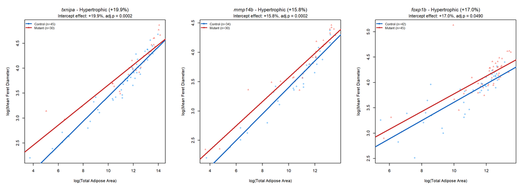

```r
# Get genes with significant intercept effects
int_sig_genes_list <- lmm_results$gene[lmm_results$intercept_sig]

if (length(int_sig_genes_list) > 0) {

  # Set up plot grid
  n_plots <- length(int_sig_genes_list)
  n_cols <- min(n_plots, 3)
  n_rows <- ceiling(n_plots / 3)
  par(mfrow = c(n_rows, n_cols), mar = c(5, 5, 4, 2))

  for (gene in int_sig_genes_list) {

    # Get data for this gene
    gene_data <- all_data[all_data$gene == gene, ]
    gene_data <- gene_data[!is.na(gene_data$AreaSum) & !is.na(gene_data$Feret) &
                           gene_data$AreaSum > 0 & gene_data$Feret > 0, ]

    ctrl <- gene_data[gene_data$genotype == "control", ]
    mut <- gene_data[gene_data$genotype == "mutant", ]

    # Get intercept effect info
    int_info <- lmm_results[lmm_results$gene == gene, ]

    # Plot on LOG-LOG scale to match LMM model
    plot(log(ctrl$AreaSum), log(ctrl$Feret),
         col = adjustcolor("#2196F3", 0.5), pch = 16, cex = 0.8,
         xlim = range(log(gene_data$AreaSum), na.rm = TRUE),
         ylim = range(log(gene_data$Feret), na.rm = TRUE),
         xlab = "log(Total Adipose Area)",
         ylab = "log(Mean Feret Diameter)",
         main = substitute(paste(italic(g), " - ", dir, " (", eff, "%)"),
                          list(g = gene, dir = int_info$direction,
                               eff = sprintf("%+.1f", int_info$intercept_pct))))

    points(log(mut$AreaSum), log(mut$Feret),
           col = adjustcolor("#F44336", 0.5), pch = 17, cex = 0.8)

    # Add regression lines on log-log scale
    if (nrow(ctrl) >= 3) {
      ctrl_lm <- lm(log(Feret) ~ log(AreaSum), data = ctrl)
      abline(ctrl_lm, col = "#1565C0", lwd = 2.5)
    }
    if (nrow(mut) >= 3) {
      mut_lm <- lm(log(Feret) ~ log(AreaSum), data = mut)
      abline(mut_lm, col = "#C62828", lwd = 2.5)
    }

    # Add legend
    legend("topleft",
           legend = c(paste0("Control (n=", nrow(ctrl), ")"),
                     paste0("Mutant (n=", nrow(mut), ")")),
           col = c("#1565C0", "#C62828"),
           pch = c(16, 17), lty = 1, lwd = 2,
           bty = "n", cex = 0.8)

    # Add p-value annotation
    mtext(sprintf("Intercept effect: %+.1f%%, adj.p = %.4f",
                  int_info$intercept_pct, int_info$intercept_p_adj),
          side = 3, line = 0.3, cex = 0.7)
  }

  par(mfrow = c(1, 1))
} else {
  cat("No genes with significant intercept effects to plot.\n")
}
```

## LMM Results: Slope (Interaction)

This tests whether the size-scaling relationship differs between mutants and controls (from a separate interaction model). A significant slope difference indicates a size-dependent phenotype.

```r
# Sort by slope p-value for this table
lmm_slope_sorted <- lmm_results[order(lmm_results$slope_p), ]

lmm_slope_display <- data.frame(
  Gene = lmm_slope_sorted$gene_md,
  n_ctrl = lmm_slope_sorted$n_ctrl,
  n_expt = lmm_slope_sorted$n_expt,
  Slope_diff = sprintf("%+.4f", lmm_slope_sorted$slope_effect),
  t = sprintf("%.2f", lmm_slope_sorted$slope_t),
  p_raw = ifelse(lmm_slope_sorted$slope_p < 0.001, sprintf("%.2e", lmm_slope_sorted$slope_p), sprintf("%.4f", lmm_slope_sorted$slope_p)),
  p_adj = ifelse(lmm_slope_sorted$slope_p_adj < 0.001, sprintf("%.2e", lmm_slope_sorted$slope_p_adj), sprintf("%.4f", lmm_slope_sorted$slope_p_adj)),
  Sig = ifelse(lmm_slope_sorted$slope_sig, "***", "")
)

kable(lmm_slope_display,
      col.names = c("Gene", "n (ctrl)", "n (expt)", "Slope diff", "t", "p (raw)", "p (adj)", "Sig."),
      caption = "LMM Slope Effects: Size-dependent phenotype (interaction term)",
      align = c("l", "c", "c", "r", "r", "r", "r", "c")) %>%
  kable_styling(bootstrap_options = c("striped", "hover", "condensed"), full_width = FALSE) %>%
  row_spec(which(lmm_slope_sorted$slope_sig), bold = TRUE, background = "#fff3cd")
```

LMM Slope Effects: Size-dependent phenotype (interaction term)

| Gene | n (ctrl) | n (expt) | Slope diff | t | p (raw) | p (adj) | Sig. |
| --- | --- | --- | --- | --- | --- | --- | --- |
| *txnipa* | 45 | 30 | -0.0505 | -3.21 | 0.0020 | 0.0255 | *** |
| *tbx15* | 37 | 26 | +0.1070 | 3.17 | 0.0024 | 0.0255 | *** |
| *srpx* | 36 | 20 | -0.0411 | -2.25 | 0.0291 | 0.2039 |  |
| *mmp14b* | 34 | 30 | -0.0233 | -1.80 | 0.0772 | 0.4024 |  |
| *kazna* | 36 | 23 | +0.0513 | 1.70 | 0.0958 | 0.4024 |  |
| *pid1* | 27 | 26 | +0.0333 | 1.43 | 0.1581 | 0.4819 |  |
| *tmem115* | 27 | 29 | -0.0468 | -1.34 | 0.1872 | 0.4819 |  |
| *cd81a* | 24 | 26 | +0.0386 | 1.31 | 0.1981 | 0.4819 |  |
| *lrmda* | 27 | 22 | +0.0301 | 1.28 | 0.2065 | 0.4819 |  |
| *runx1t1* | 29 | 22 | -0.0356 | -1.03 | 0.3067 | 0.5988 |  |
| *nav3* | 49 | 42 | +0.0215 | 1.01 | 0.3136 | 0.5988 |  |
| *ptprdb* | 35 | 24 | -0.0226 | -0.76 | 0.4500 | 0.7874 |  |
| *ptenb* | 27 | 25 | -0.0196 | -0.67 | 0.5081 | 0.8161 |  |
| *pard3ab* | 36 | 32 | -0.0127 | -0.54 | 0.5917 | 0.8161 |  |
| *cacnb4a* | 29 | 27 | +0.0120 | 0.47 | 0.6419 | 0.8161 |  |
| *sdk1a* | 29 | 25 | -0.0141 | -0.43 | 0.6704 | 0.8161 |  |
| *cxcl14* | 27 | 24 | +0.0095 | 0.41 | 0.6824 | 0.8161 |  |
| *sparc* | 24 | 23 | +0.0131 | 0.39 | 0.6995 | 0.8161 |  |
| *prrx1b* | 65 | 60 | -0.0046 | -0.25 | 0.8035 | 0.8505 |  |
| *ptprga* | 35 | 35 | +0.0065 | 0.24 | 0.8100 | 0.8505 |  |
| *foxp1b* | 42 | 45 | -0.0056 | -0.18 | 0.8539 | 0.8539 |  |

```r
lmm_slope_sig <- lmm_results[lmm_results$slope_sig, ]
cat("**Significant slope effects (BH-adjusted p < 0.05):**\n\n")
```

**Significant slope effects (BH-adjusted p < 0.05):**

```r
if (nrow(lmm_slope_sig) > 0) {
  for (i in 1:nrow(lmm_slope_sig)) {
    direction <- ifelse(lmm_slope_sig$slope_effect[i] > 0, "steeper", "shallower")
    cat(sprintf("- **%s**: %s slope (%+.4f, adj.p = %.4f)\n",
                lmm_slope_sig$gene_md[i], direction,
                lmm_slope_sig$slope_effect[i], lmm_slope_sig$slope_p_adj[i]))
  }
} else {
  cat("None\n")
}
```

- *txnipa*: shallower slope (-0.0505, adj.p = 0.0255)
- *tbx15*: steeper slope (+0.1070, adj.p = 0.0255)

### Slope Interaction Plots for Significant Genes

The following plots show the size-scaling relationship (log(AreaSum) vs log(Feret)) for genes with significant slope differences. This matches the LMM model specification. A steeper or shallower slope in mutants indicates that the phenotype magnitude depends on fish size.

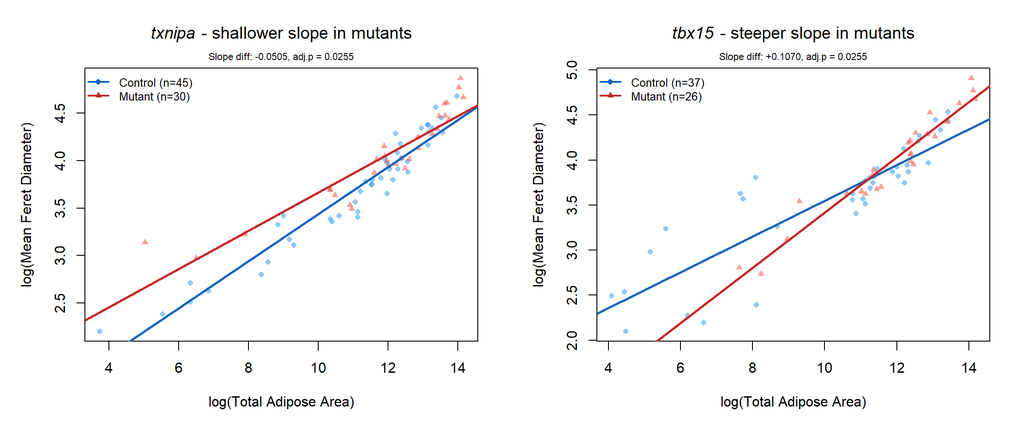

```r
# Get genes with significant slope effects
slope_sig_genes_list <- lmm_results$gene[lmm_results$slope_sig]

if (length(slope_sig_genes_list) > 0) {

  # Set up plot grid
  n_plots <- length(slope_sig_genes_list)
  par(mfrow = c(1, min(n_plots, 3)), mar = c(5, 5, 4, 2))

  for (gene in slope_sig_genes_list) {

    # Get data for this gene
    gene_data <- all_data[all_data$gene == gene, ]
    gene_data <- gene_data[!is.na(gene_data$AreaSum) & !is.na(gene_data$Feret) &
                           gene_data$AreaSum > 0 & gene_data$Feret > 0, ]

    ctrl <- gene_data[gene_data$genotype == "control", ]
    mut <- gene_data[gene_data$genotype == "mutant", ]

    # Get slope effect info
    slope_info <- lmm_results[lmm_results$gene == gene, ]
    slope_dir <- ifelse(slope_info$slope_effect > 0, "steeper", "shallower")

    # Plot on LOG-LOG scale to match LMM model: log(Feret) ~ log(AreaSum)
    plot(log(ctrl$AreaSum), log(ctrl$Feret),
         col = adjustcolor("#2196F3", 0.5), pch = 16, cex = 0.8,
         xlim = range(log(gene_data$AreaSum), na.rm = TRUE),
         ylim = range(log(gene_data$Feret), na.rm = TRUE),
         xlab = "log(Total Adipose Area)",
         ylab = "log(Mean Feret Diameter)",
         main = substitute(paste(italic(g), " - ", dir, " slope in mutants"),
                          list(g = gene, dir = slope_dir)))

    points(log(mut$AreaSum), log(mut$Feret),
           col = adjustcolor("#F44336", 0.5), pch = 17, cex = 0.8)

    # Add regression lines on log-log scale (matching the LMM)
    if (nrow(ctrl) >= 3) {
      ctrl_lm <- lm(log(Feret) ~ log(AreaSum), data = ctrl)
      abline(ctrl_lm, col = "#1565C0", lwd = 2.5)
    }
    if (nrow(mut) >= 3) {
      mut_lm <- lm(log(Feret) ~ log(AreaSum), data = mut)
      abline(mut_lm, col = "#C62828", lwd = 2.5)
    }

    # Add legend
    legend("topleft",
           legend = c(paste0("Control (n=", nrow(ctrl), ")"),
                     paste0("Mutant (n=", nrow(mut), ")")),
           col = c("#1565C0", "#C62828"),
           pch = c(16, 17), lty = 1, lwd = 2,
           bty = "n", cex = 0.8)

    # Add p-value annotation
    mtext(sprintf("Slope diff: %+.4f, adj.p = %.4f",
                  slope_info$slope_effect, slope_info$slope_p_adj),
          side = 3, line = 0.3, cex = 0.7)
  }

  par(mfrow = c(1, 1))
} else {
  cat("No genes with significant slope effects to plot.\n")
}
```

## Summary: Intercept vs Slope Effects

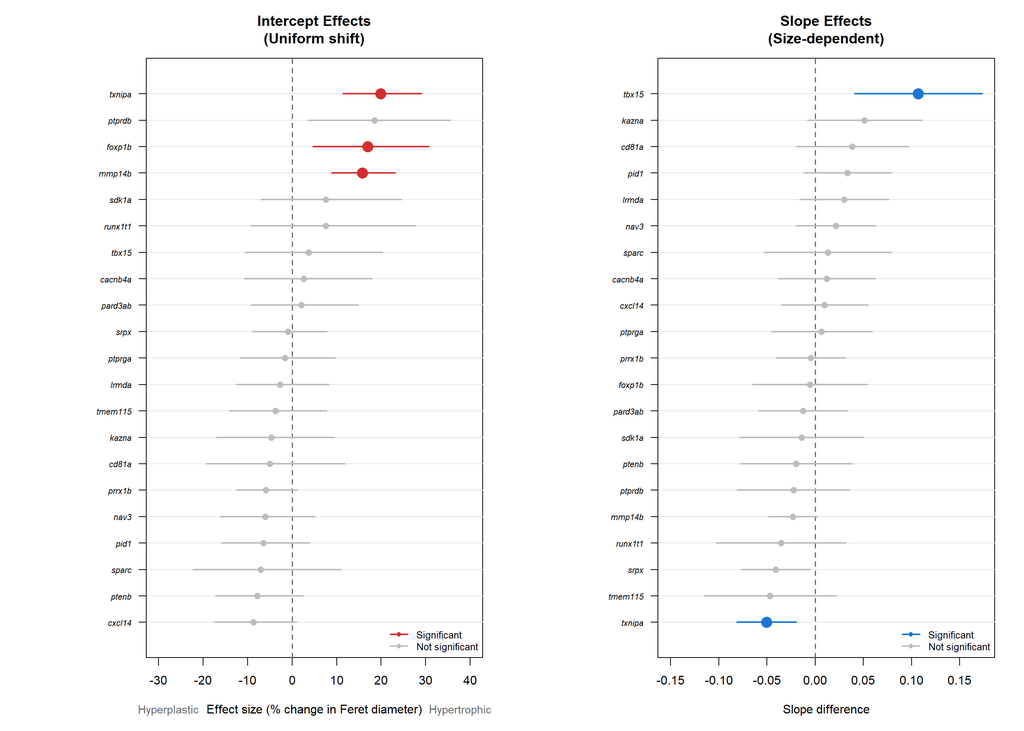

```r
par(mfrow = c(1, 2), mar = c(5, 10, 4, 2))

# Colours
col_int_sig <- "#D32F2F"
col_slope_sig <- "#1976D2"
col_ns <- "#BDBDBD"

# --- Panel 1: Intercept effects ---
plot_data1 <- lmm_results[order(lmm_results$intercept_pct), ]
n_genes <- nrow(plot_data1)

# Calculate 95% CI
plot_data1$int_ci_lower <- (exp(plot_data1$intercept_effect - 1.96 * plot_data1$intercept_se) - 1) * 100
plot_data1$int_ci_upper <- (exp(plot_data1$intercept_effect + 1.96 * plot_data1$intercept_se) - 1) * 100

plot_data1$color <- ifelse(plot_data1$intercept_sig, col_int_sig, col_ns)

plot(NULL,
     xlim = c(min(plot_data1$int_ci_lower, -30, na.rm = TRUE), max(plot_data1$int_ci_upper, 40, na.rm = TRUE)),
     ylim = c(0.5, n_genes + 0.5),
     xlab = "Effect size (% change in Feret diameter)",
     ylab = "",
     yaxt = "n",
     main = "Intercept Effects\n(Uniform shift)")

abline(v = 0, lty = 2, col = "gray40", lwd = 1.5)
abline(h = 1:n_genes, col = "gray90", lty = 1)

for (i in 1:n_genes) {
  segments(plot_data1$int_ci_lower[i], i, plot_data1$int_ci_upper[i], i, col = plot_data1$color[i], lwd = 2)
  pch_size <- ifelse(plot_data1$intercept_sig[i], 2, 1.2)
  points(plot_data1$intercept_pct[i], i, pch = 16, col = plot_data1$color[i], cex = pch_size)
}

# Use gene names directly
axis(2, at = 1:n_genes, labels = plot_data1$gene, las = 1, cex.axis = 0.7, font = 3)
legend("bottomright", legend = c("Significant", "Not significant"),
       col = c(col_int_sig, col_ns), pch = 16, lty = 1, lwd = 2, bty = "n", cex = 0.8)

mtext("Hyperplastic", side = 1, at = par("usr")[1] + 5, line = 3, cex = 0.9, col = "gray40")
mtext("Hypertrophic", side = 1, at = par("usr")[2] - 5, line = 3, cex = 0.9, col = "gray40")

# --- Panel 2: Slope effects ---
plot_data2 <- lmm_results[order(lmm_results$slope_effect), ]

# Calculate 95% CI for slope
plot_data2$slope_ci_lower <- plot_data2$slope_effect - 1.96 * plot_data2$slope_se
plot_data2$slope_ci_upper <- plot_data2$slope_effect + 1.96 * plot_data2$slope_se

plot_data2$color <- ifelse(plot_data2$slope_sig, col_slope_sig, col_ns)

plot(NULL,
     xlim = c(min(plot_data2$slope_ci_lower, -0.15, na.rm = TRUE), max(plot_data2$slope_ci_upper, 0.15, na.rm = TRUE)),
     ylim = c(0.5, n_genes + 0.5),
     xlab = "Slope difference",
     ylab = "",
     yaxt = "n",
     main = "Slope Effects\n(Size-dependent)")

abline(v = 0, lty = 2, col = "gray40", lwd = 1.5)
abline(h = 1:n_genes, col = "gray90", lty = 1)

for (i in 1:n_genes) {
  segments(plot_data2$slope_ci_lower[i], i, plot_data2$slope_ci_upper[i], i, col = plot_data2$color[i], lwd = 2)
  pch_size <- ifelse(plot_data2$slope_sig[i], 2, 1.2)
  points(plot_data2$slope_effect[i], i, pch = 16, col = plot_data2$color[i], cex = pch_size)
}

axis(2, at = 1:n_genes, labels = plot_data2$gene, las = 1, cex.axis = 0.7, font = 3)
legend("bottomright", legend = c("Significant", "Not significant"),
       col = c(col_slope_sig, col_ns), pch = 16, lty = 1, lwd = 2, bty = "n", cex = 0.8)
```

```r
# Add LMM significance to stratified_df for three-way validation
if (exists("stratified_df") && nrow(stratified_df) > 0) {
  stratified_df$lmm_sig <- FALSE
  for (i in 1:nrow(stratified_df)) {
    g <- stratified_df$gene[i]
    if (g %in% lmm_results$gene) {
      stratified_df$lmm_sig[i] <- lmm_results$intercept_p_adj[lmm_results$gene == g] < 0.05
    }
  }
}
```

# Analysis 3: Single-Experiment Genes (*aspa* and *lamb2*)

Genes *aspa* and *lamb2* had only one experiment each, so batch correction via random effects is not possible. We analyse these separately.

**Note:** These results are not directly comparable to the batch-corrected results and should be interpreted with caution.

```r
single_results <- list()

for (gene in single_expt_genes) {

  ctrl_data <- all_data[all_data$gene == gene & all_data$genotype == "control", ]
  expt_data <- all_data[all_data$gene == gene & all_data$genotype == "mutant", ]

  if (nrow(ctrl_data) < 3 || nrow(expt_data) < 3) next

  # Clean
  ctrl_data <- ctrl_data[!is.na(ctrl_data$AreaSum) & ctrl_data$AreaSum > 0 &
                         !is.na(ctrl_data$Feret) & ctrl_data$Feret > 0, ]
  expt_data <- expt_data[!is.na(expt_data$AreaSum) & expt_data$AreaSum > 0 &
                         !is.na(expt_data$Feret) & expt_data$Feret > 0, ]

  cat("### *", gene, "* (n_ctrl = ", nrow(ctrl_data), ", n_expt = ", nrow(expt_data), ")\n\n", sep = "")

  # KS Test
  gam_model <- gam(Feret ~ s(log(AreaSum)), data = ctrl_data)
  ctrl_residuals <- residuals(gam_model)
  pred <- predict(gam_model, newdata = data.frame(AreaSum = expt_data$AreaSum))
  expt_deviations <- expt_data$Feret - pred
  ks_result <- ks.test(ctrl_residuals, expt_deviations)

  ks_effect <- mean(expt_deviations)
  ks_p <- ks_result$p.value

  # LM (no random effects)
  combined <- rbind(
    data.frame(AreaSum = ctrl_data$AreaSum, Feret = ctrl_data$Feret, genotype = "control"),
    data.frame(AreaSum = expt_data$AreaSum, Feret = expt_data$Feret, genotype = "mutant")
  )
  combined$log_Feret <- log(combined$Feret)
  combined$log_AreaSum <- log(combined$AreaSum)
  combined$genotype <- factor(combined$genotype, levels = c("control", "mutant"))

  model <- lm(log_Feret ~ log_AreaSum + genotype, data = combined)
  coefs <- summary(model)$coefficients

  lm_effect <- (exp(coefs["genotypemutant", 1]) - 1) * 100
  lm_p <- coefs["genotypemutant", 4]
  direction <- ifelse(lm_effect > 0, "Hypertrophic", "Hyperplastic")

  single_results[[gene]] <- data.frame(
    gene = gene,
    n_ctrl = nrow(ctrl_data),
    n_expt = nrow(expt_data),
    KS_effect_um = round(ks_effect, 2),
    KS_p = ks_p,
    KS_sig = ks_p < 0.05,
    LM_effect_pct = round(lm_effect, 2),
    LM_p = lm_p,
    LM_sig = lm_p < 0.05,
    direction = direction,
    stringsAsFactors = FALSE
  )

  cat("**KS Test:** ", sprintf("%+.2f um (p = %.4f, %s)\n\n", ks_effect, ks_p, ifelse(ks_p < 0.05, "significant", "NS")), sep = "")
  cat("**Linear Model:** ", sprintf("%+.2f%% (p = %.4f, %s)\n\n", lm_effect, lm_p, ifelse(lm_p < 0.05, "significant", "NS")), sep = "")
}
```

```
## ### *aspa* (n_ctrl = 18, n_expt = 17)
##
## **KS Test:** +6.05 um (p = 0.0026, significant)
##
## **Linear Model:** +16.67% (p = 0.0208, significant)
##
## ### *lamb2* (n_ctrl = 18, n_expt = 5)
##
## **KS Test:** -3.32 um (p = 0.3586, NS)
##
## **Linear Model:** +15.08% (p = 0.3211, NS)
```

```r
single_results <- do.call(rbind, single_results)
```

## Summary Table: Single-Experiment Genes

```r
if (exists("single_results") && !is.null(single_results) && nrow(single_results) > 0) {
  single_display <- data.frame(
    Gene = sapply(single_results$gene, function(x) format_gene_name(x, italics = TRUE)),
    n_ctrl = single_results$n_ctrl,
    n_expt = single_results$n_expt,
    KS_effect = sprintf("%+.2f", single_results$KS_effect_um),
    KS_p = sprintf("%.4f", single_results$KS_p),
    KS_sig = ifelse(single_results$KS_sig, "*", ""),
    LM_effect = sprintf("%+.2f%%", single_results$LM_effect_pct),
    LM_p = sprintf("%.4f", single_results$LM_p),
    LM_sig = ifelse(single_results$LM_sig, "*", ""),
    Direction = single_results$direction
  )

  kable(single_display,
        col.names = c("Gene", "n (ctrl)", "n (expt)", "KS Effect (um)", "KS p", "Sig", "LM Effect (%)", "LM p", "Sig", "Direction"),
        caption = "Single-Experiment Genes: Results without batch correction") %>%
    kable_styling(bootstrap_options = c("striped", "hover", "condensed"), full_width = FALSE)
}
```

Single-Experiment Genes: Results without batch correction

Gene

n (ctrl)

n (expt)

KS Effect (um)

KS p

Sig

LM Effect (%)

LM p

Sig

Direction

aspa

*aspa*

18

17

+6.05

0.0026

+16.67%

0.0208

Hypertrophic

lamb2

*lamb2*

18

5

-3.32

0.3586

+15.08%

0.3211

Hypertrophic

# Combined Results

## Comparison Table

The combined table integrates results from pooled KS tests, stratified (within-experiment) KS tests, and LMM analysis.

**Important:** Genes are considered “robust” if they are significant in both **stratified KS** (which controls for batch effects) AND **LMM** (which uses experiment as a random effect). The stratified KS is preferred over pooled KS because it validates that effects are consistent within experiments rather than driven by between-experiment differences.

```r
# Merge KS and LMM results
combined_results <- merge(ks_results, lmm_results, by = "gene", suffixes = c("_ks", "_lmm"))

# Add stratified KS results if available
if (exists("stratified_df") && nrow(stratified_df) > 0) {
  stratified_subset <- stratified_df[, c("gene", "stratified_p_adj", "stratified_sig", "stratified_effect", "agreement")]
  names(stratified_subset) <- c("gene", "stratified_KS_p_adj", "stratified_KS_sig", "stratified_KS_effect", "KS_agreement")
  combined_results <- merge(combined_results, stratified_subset, by = "gene", all.x = TRUE)

  # Fill NAs for genes without stratified results
  combined_results$stratified_KS_p_adj[is.na(combined_results$stratified_KS_p_adj)] <- NA
  combined_results$stratified_KS_sig[is.na(combined_results$stratified_KS_sig)] <- FALSE
} else {
  combined_results$stratified_KS_p_adj <- NA
  combined_results$stratified_KS_sig <- FALSE
  combined_results$stratified_KS_effect <- NA
  combined_results$KS_agreement <- NA
}

# Sort by LMM intercept p-value
combined_results <- combined_results[order(combined_results$intercept_p), ]

# Determine consensus using STRATIFIED KS (more robust than pooled)
# A gene is "robust" if significant in stratified KS AND LMM
combined_results$robust_sig <- combined_results$stratified_KS_sig & combined_results$intercept_sig

# Also track pooled-only significance for comparison (legacy)
combined_results$both_sig <- combined_results$KS_sig & combined_results$intercept_sig

# Calculate power for large effects only (d = 0.8)
combined_results$power_large <- mapply(calc_power, combined_results$n_ctrl_ks, combined_results$n_expt_ks, d = 0.8)

# Get number of experiments per gene from stratified_df
if (exists("stratified_df")) {
  n_expts_lookup <- setNames(stratified_df$n_experiments, stratified_df$gene)
  combined_results$n_expts <- n_expts_lookup[combined_results$gene]
  combined_results$n_expts[is.na(combined_results$n_expts)] <- 1  # Default for genes not in stratified
} else {
  combined_results$n_expts <- NA
}

# Display table with both pooled and stratified KS
combined_display <- data.frame(
  Gene = sapply(combined_results$gene, function(x) format_gene_name(x, italics = TRUE)),
  n_expts = combined_results$n_expts,
  n = paste0(combined_results$n_ctrl_ks, "/", combined_results$n_expt_ks),
  KS_effect = sprintf("%+.1f", combined_results$effect_um),
  Pooled_KS_p = ifelse(combined_results$KS_p_adj < 0.001, sprintf("%.2e", combined_results$KS_p_adj), sprintf("%.3f", combined_results$KS_p_adj)),
  Pooled_KS_sig = ifelse(combined_results$KS_sig, "***", ""),
  Strat_KS_p = ifelse(is.na(combined_results$stratified_KS_p_adj), "-",
                       ifelse(combined_results$stratified_KS_p_adj < 0.001,
                              sprintf("%.2e", combined_results$stratified_KS_p_adj),
                              sprintf("%.3f", combined_results$stratified_KS_p_adj))),
  Strat_KS_sig = ifelse(combined_results$stratified_KS_sig, "***", ""),
  LMM_effect = sprintf("%+.1f%%", combined_results$intercept_pct),
  LMM_p = ifelse(combined_results$intercept_p_adj < 0.001, sprintf("%.2e", combined_results$intercept_p_adj), sprintf("%.3f", combined_results$intercept_p_adj)),
  LMM_sig = ifelse(combined_results$intercept_sig, "***", ""),
  Direction = combined_results$direction_ks,
  Power_L = paste0(combined_results$power_large, "%")
)

kable(combined_display,
      col.names = c("Gene", "Expts", "n (ctrl/mut)", "Effect (um)", "Pooled p", "Sig", "Strat. p", "Sig", "Effect (%)", "LMM p (adj)", "Sig", "Direction", "Power (d=0.8)"),
      caption = "Combined KS and LMM Results (green = significant in stratified KS AND LMM)",
      align = c("l", "c", "c", "r", "r", "c", "r", "c", "r", "r", "c", "l", "c")) %>%
  kable_styling(bootstrap_options = c("striped", "hover", "condensed"), full_width = FALSE, font_size = 10) %>%
  row_spec(which(combined_results$robust_sig), bold = TRUE, background = "#d4edda")
```

Combined KS and LMM Results (green = significant in stratified KS AND LMM)

|  | Gene | Expts | n (ctrl/mut) | Effect (um) | Pooled p | Sig | Strat. p | Sig | Effect (%) | LMM p (adj) | Sig | Direction | Power (d=0.8) |
| --- | --- | --- | --- | --- | --- | --- | --- | --- | --- | --- | --- | --- | --- |
| txnipa | *txnipa* | 3 | 45/30 | +4.6 | 0.066 |  | 1.41e-04 | *** | +19.9% | 1.63e-04 | *** | Hypertrophic | 92% |
| mmp14b | *mmp14b* | 2 | 34/30 | +5.4 | 0.002 | *** | 0.005 | *** | +15.8% | 1.93e-04 | *** | Hypertrophic | 88% |
| foxp1b | *foxp1b* | 2 | 42/45 | +8.8 | 0.064 |  | 0.019 | *** | +17.0% | 0.049 | *** | Hypertrophic | 96% |
| ptprdb | *ptprdb* | 2 | 35/24 | +4.0 | 0.080 |  | 0.057 |  | +18.5% | 0.087 |  | Hypertrophic | 84% |
| cxcl14 | *cxcl14* | 2 | 27/24 | -4.4 | 0.522 |  | 0.077 |  | -8.7% | 0.348 |  | Hyperplastic | 80% |
| prrx1b | *prrx1b* | 3 | 65/60 | -3.5 | 0.178 |  | 0.077 |  | -5.9% | 0.358 |  | Hyperplastic | 99% |
| ptenb | *ptenb* | 2 | 27/25 | -4.7 | 0.054 |  | 0.077 |  | -7.9% | 0.411 |  | Hyperplastic | 81% |
| pid1 | *pid1* | 2 | 27/26 | -2.7 | 0.869 |  | 0.204 |  | -6.5% | 0.565 |  | Hyperplastic | 81% |
| nav3 | *nav3* | 3 | 49/42 | -2.4 | 0.194 |  | 0.562 |  | -6.1% | 0.650 |  | Hyperplastic | 96% |
| sdk1a | *sdk1a* | 2 | 29/25 | +0.6 | 0.869 |  | 0.482 |  | +7.6% | 0.694 |  | Hypertrophic | 82% |
| runx1t1 | *runx1t1* | 2 | 29/22 | +1.1 | 0.706 |  | 0.795 |  | +7.6% | 0.736 |  | Hypertrophic | 79% |
| sparc | *sparc* | 2 | 24/23 | -2.1 | 0.286 |  | 0.553 |  | -7.1% | 0.736 |  | Hyperplastic | 77% |
| kazna | *kazna* | 2 | 36/23 | -3.1 | 0.706 |  | 0.148 |  | -4.7% | 0.759 |  | Hyperplastic | 84% |
| tmem115 | *tmem115* | 2 | 27/29 | -3.1 | 0.488 |  | 0.019 | *** | -3.8% | 0.759 |  | Hyperplastic | 84% |
| cd81a | *cd81a* | 2 | 24/26 | +0.0 | 0.862 |  | 0.064 |  | -5.0% | 0.759 |  | Hypertrophic | 79% |
| lrmda | *lrmda* | 2 | 27/22 | -0.4 | 0.527 |  | 0.077 |  | -2.7% | 0.778 |  | Hyperplastic | 78% |
| tbx15 | *tbx15* | 3 | 37/26 | +3.4 | 0.706 |  | 0.019 | *** | +3.7% | 0.778 |  | Hypertrophic | 87% |
| cacnb4a | *cacnb4a* | 2 | 29/27 | +0.9 | 0.706 |  | 0.852 |  | +2.6% | 0.804 |  | Hypertrophic | 84% |
| pard3ab | *pard3ab* | 2 | 36/32 | -1.5 | 0.869 |  | 0.750 |  | +2.1% | 0.804 |  | Hyperplastic | 90% |
| ptprga | *ptprga* | 2 | 35/35 | -1.4 | 0.269 |  | 0.077 |  | -1.6% | 0.804 |  | Hyperplastic | 91% |
| srpx | *srpx* | 2 | 36/20 | -5.7 | 0.155 |  | 0.204 |  | -0.9% | 0.836 |  | Hyperplastic | 80% |

## Summary

```r
both_sig_genes <- combined_results$gene[combined_results$both_sig]
robust_sig_genes <- combined_results$gene[combined_results$robust_sig]
ks_only <- combined_results$gene[combined_results$KS_sig & !combined_results$intercept_sig]
lmm_only <- combined_results$gene[!combined_results$KS_sig & combined_results$intercept_sig]
# Also find genes significant in stratified KS + LMM but not pooled KS
strat_lmm_only <- combined_results$gene[combined_results$robust_sig & !combined_results$KS_sig]
slope_sig_genes <- lmm_results$gene[lmm_results$slope_sig]

cat("## Robust Findings\n\n")
```

## Robust Findings

```r
# Primary: Stratified KS + LMM (most robust)
if (length(robust_sig_genes) > 0) {
  cat("The following genes showed significant **intercept** (uniform shift) phenotypes in both **stratified KS** (within-experiment validation) AND **LMM** (batch-corrected). These represent the highest-confidence findings:\n\n")

  for (gene in sort(robust_sig_genes)) {
    gene_data <- combined_results[combined_results$gene == gene, ]
    gene_md <- format_gene_name(gene, italics = TRUE)

    # Note if also significant in pooled KS
    pooled_note <- ""
    if (gene_data$KS_sig) {
      pooled_note <- ", pooled KS ***"
    }

    cat(sprintf("- **%s**: %s (%+.1f um / %+.1f%%, stratified KS adj.p = %.4f, LMM adj.p = %.4f%s)\n",
                gene_md,
                gene_data$direction_ks,
                gene_data$effect_um,
                gene_data$intercept_pct,
                gene_data$stratified_KS_p_adj,
                gene_data$intercept_p_adj,
                pooled_note))
  }
  cat("\n")
} else {
  cat("No genes were significant in both stratified KS and LMM.\n\n")
}
```

The following genes showed significant **intercept** (uniform shift) phenotypes in both **stratified KS** (within-experiment validation) AND **LMM** (batch-corrected). These represent the highest-confidence findings:

- *foxp1b*: Hypertrophic (+8.8 um / +17.0%, stratified KS adj.p = 0.0194, LMM adj.p = 0.0490)
- *mmp14b*: Hypertrophic (+5.4 um / +15.8%, stratified KS adj.p = 0.0052, LMM adj.p = 0.0002, pooled KS ***)
- *txnipa*: Hypertrophic (+4.6 um / +19.9%, stratified KS adj.p = 0.0001, LMM adj.p = 0.0002)

```r
# Secondary: Pooled KS + LMM (less robust)
pooled_only_both <- setdiff(both_sig_genes, robust_sig_genes)
if (length(pooled_only_both) > 0) {
  cat("**Additional genes significant in pooled KS + LMM (but not stratified KS):**\n\n")
  for (gene in sort(pooled_only_both)) {
    gene_data <- combined_results[combined_results$gene == gene, ]
    gene_md <- format_gene_name(gene, italics = TRUE)
    cat(sprintf("- %s: %s (pooled KS adj.p = %.4f, LMM adj.p = %.4f) - *interpret with caution, may be batch artifact*\n",
                gene_md, gene_data$direction_ks, gene_data$KS_p_adj, gene_data$intercept_p_adj))
  }
  cat("\n")
}

# Slope effects
if (length(slope_sig_genes) > 0) {
  cat("## Size-Dependent Effects (Slope)\n\n")
  cat("The following genes showed significant **slope** differences, indicating size-dependent phenotypes:\n\n")
  for (gene in sort(slope_sig_genes)) {
    gene_data <- lmm_results[lmm_results$gene == gene, ]
    gene_md <- format_gene_name(gene, italics = TRUE)
    direction <- ifelse(gene_data$slope_effect > 0, "steeper", "shallower")
    cat(sprintf("- **%s**: %s slope (%+.4f, adj.p = %.4f)\n",
                gene_md, direction, gene_data$slope_effect, gene_data$slope_p_adj))
  }
  cat("\n*A steeper slope means the hypertrophic/hyperplastic phenotype is more pronounced in larger fish.*\n\n")
}
```

## Size-Dependent Effects (Slope)

The following genes showed significant **slope** differences, indicating size-dependent phenotypes:

- *tbx15*: steeper slope (+0.1070, adj.p = 0.0255)
- *txnipa*: shallower slope (-0.0505, adj.p = 0.0255)

*A steeper slope means the hypertrophic/hyperplastic phenotype is more pronounced in larger fish.*

```r
cat("## Single-Experiment Genes (*aspa*, *lamb2*)\n\n")
```

## Single-Experiment Genes (*aspa*, *lamb2*)

```r
if (exists("single_results") && !is.null(single_results) && nrow(single_results) > 0) {
  for (i in 1:nrow(single_results)) {
    gene_md <- format_gene_name(single_results$gene[i], italics = TRUE)
    ks_sig_text <- ifelse(single_results$KS_sig[i], "*", "")
    lm_sig_text <- ifelse(single_results$LM_sig[i], "*", "")
    cat(sprintf("- **%s**: %s (KS: %+.1f um, p=%.3f%s | LM: %+.1f%%, p=%.3f%s)\n",
                gene_md,
                single_results$direction[i],
                single_results$KS_effect_um[i],
                single_results$KS_p[i],
                ks_sig_text,
                single_results$LM_effect_pct[i],
                single_results$LM_p[i],
                lm_sig_text))
  }
  cat("\n*Note: These genes had only one experiment and could not be batch-corrected.*\n\n")
}
```

- *aspa*: Hypertrophic (KS: +6.0 um, p=0.003* | LM: +16.7%, p=0.021*)
- *lamb2*: Hypertrophic (KS: -3.3 um, p=0.359 | LM: +15.1%, p=0.321)

*Note: These genes had only one experiment and could not be batch-corrected.*

```r
cat("## Methodological Notes\n\n")
```

## Methodological Notes

```r
cat("1. KS tests compare full distributions; LMM tests mean differences (intercept and slope)\n")
```

1. KS tests compare full distributions; LMM tests mean differences (intercept and slope)

```r
cat("2. LMM includes experiment as random effect to account for batch variation\n")
```

2. LMM includes experiment as random effect to account for batch variation

```r
cat("3. Stratified KS tests run within each experiment and combined via Fisher's method to validate pooled results\n")
```

3. Stratified KS tests run within each experiment and combined via Fisher’s method to validate pooled results

```r
cat("4. Benjamini-Hochberg correction applied separately to intercept and slope p-values across ", nrow(lmm_results), " multi-experiment genes\n", sep = "")
```

4. Benjamini-Hochberg correction applied separately to intercept and slope p-values across 21 multi-experiment genes

```r
cat("5. Genes *aspa* and *lamb2* (single experiment) analysed separately without batch correction\n")
```

5. Genes *aspa* and *lamb2* (single experiment) analysed separately without batch correction

```r
cat("6. Genes significant in pooled KS, stratified KS, AND LMM represent the highest-confidence findings\n")
```

6. Genes significant in pooled KS, stratified KS, AND LMM represent the highest-confidence findings

## Figure: Forest Plot of Effect Sizes

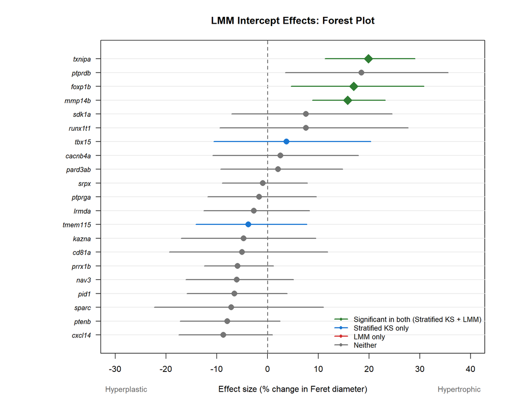

```r
# Sort by effect size for plotting
plot_data <- combined_results[order(combined_results$intercept_pct), ]

# Calculate 95% CI
plot_data$ci_lower <- (exp(plot_data$intercept_effect - 1.96 * plot_data$intercept_se) - 1) * 100
plot_data$ci_upper <- (exp(plot_data$intercept_effect + 1.96 * plot_data$intercept_se) - 1) * 100

# Colours based on significance - using STRATIFIED KS (not pooled)
col_both <- "#2E7D32"
col_ks_only <- "#1976D2"
col_lmm_only <- "#D32F2F"
col_neither <- "#757575"

plot_data$color <- col_neither
plot_data$color[plot_data$stratified_KS_sig & !plot_data$intercept_sig] <- col_ks_only
plot_data$color[!plot_data$stratified_KS_sig & plot_data$intercept_sig] <- col_lmm_only
plot_data$color[plot_data$robust_sig] <- col_both

# Set up plot
n_genes <- nrow(plot_data)
par(mar = c(5, 10, 4, 2))

# Create empty plot
plot(NULL,
     xlim = c(min(plot_data$ci_lower, -30, na.rm = TRUE), max(plot_data$ci_upper, 40, na.rm = TRUE)),
     ylim = c(0.5, n_genes + 0.5),
     xlab = "Effect size (% change in Feret diameter)",
     ylab = "",
     yaxt = "n",
     main = "LMM Intercept Effects: Forest Plot")

# Add vertical line at 0
abline(v = 0, lty = 2, col = "gray40", lwd = 1.5)

# Add horizontal grid lines
abline(h = 1:n_genes, col = "gray90", lty = 1)

# Plot points and CIs
for (i in 1:n_genes) {
  y_pos <- i

  # Draw CI line
  segments(plot_data$ci_lower[i], y_pos, plot_data$ci_upper[i], y_pos,
           col = plot_data$color[i], lwd = 2)

  # Draw point (larger for significant)
  pch_size <- ifelse(plot_data$robust_sig[i], 2.5, 1.5)
  points(plot_data$intercept_pct[i], y_pos,
         pch = ifelse(plot_data$robust_sig[i], 18, 16),
         col = plot_data$color[i],
         cex = pch_size)
}

# Add gene names on y-axis (use gene names directly, italicized)
axis(2, at = 1:n_genes, labels = plot_data$gene, las = 1, cex.axis = 0.8, font = 3)

# Add legend
legend("bottomright",
       legend = c("Significant in both (Stratified KS + LMM)", "Stratified KS only", "LMM only", "Neither"),
       col = c(col_both, col_ks_only, col_lmm_only, col_neither),
       pch = c(18, 16, 16, 16),
       lty = 1, lwd = 2,
       bty = "n", cex = 0.85)

# Add text annotations for direction
mtext("Hyperplastic", side = 1, at = par("usr")[1] + 5, line = 3, cex = 0.9, col = "gray40")
mtext("Hypertrophic", side = 1, at = par("usr")[2] - 5, line = 3, cex = 0.9, col = "gray40")
```

# Variance and Heterogeneity Analysis

This section examines whether mutants show altered variance (heterogeneity) compared to controls, beyond simple mean shifts.

```r
# Functions
cv <- function(x) sd(x, na.rm = TRUE) / abs(mean(x, na.rm = TRUE)) * 100
tail_weight <- function(x) {
  x <- x[!is.na(x)]
  m <- mean(x)
  s <- sd(x)
  sum(abs(x - m) > 2 * s) / length(x) * 100
}

# Calculate variance metrics for each gene
variance_results <- list()

for (gene in gene_names) {

  ctrl_data <- all_data[all_data$gene == gene & all_data$genotype == "control", ]
  expt_data <- all_data[all_data$gene == gene & all_data$genotype == "mutant", ]

  ctrl_data <- ctrl_data[!is.na(ctrl_data$AreaSum) & ctrl_data$AreaSum > 0 &
                         !is.na(ctrl_data$Feret) & ctrl_data$Feret > 0, ]
  expt_data <- expt_data[!is.na(expt_data$AreaSum) & expt_data$AreaSum > 0 &
                         !is.na(expt_data$Feret) & expt_data$Feret > 0, ]

  if (nrow(ctrl_data) < 10 | nrow(expt_data) < 10) next

  # Calculate morphology value
  gam_model <- gam(Feret ~ s(log(AreaSum)), data = ctrl_data)
  ctrl_residuals <- residuals(gam_model)
  pred_expt <- predict(gam_model, newdata = data.frame(AreaSum = expt_data$AreaSum))
  expt_deviations <- expt_data$Feret - pred_expt

  # Statistics
  var_ctrl <- var(ctrl_residuals)
  var_expt <- var(expt_deviations)
  var_ratio <- var_expt / var_ctrl
  var_test <- var.test(expt_deviations, ctrl_residuals)

  # Skewness and kurtosis
  if (require(moments, quietly = TRUE)) {
    skew_expt <- skewness(expt_deviations)
    kurt_expt <- kurtosis(expt_deviations) - 3  # Excess kurtosis
  } else {
    skew_expt <- NA
    kurt_expt <- NA
  }

  variance_results[[gene]] <- data.frame(
    gene = gene,
    n_ctrl = length(ctrl_residuals),
    n_expt = length(expt_deviations),
    sd_ctrl = round(sd(ctrl_residuals), 2),
    sd_expt = round(sd(expt_deviations), 2),
    var_ratio = round(var_ratio, 3),
    var_p = var_test$p.value,
    skewness = round(skew_expt, 3),
    kurtosis = round(kurt_expt, 3),
    tail_pct = round(tail_weight(expt_deviations), 1),
    stringsAsFactors = FALSE
  )
}

variance_df <- do.call(rbind, variance_results)
rownames(variance_df) <- NULL

# BH correction
variance_df$var_p_adj <- p.adjust(variance_df$var_p, method = "BH")
variance_df$var_sig <- variance_df$var_p_adj < 0.05

# Sort by variance ratio
variance_df <- variance_df[order(-variance_df$var_ratio), ]
```

## Variance Comparison Table

```r
variance_display <- data.frame(
  Gene = sapply(variance_df$gene, function(x) format_gene_name(x, italics = TRUE)),
  n = paste0(variance_df$n_ctrl, "/", variance_df$n_expt),
  SD_ctrl = sprintf("%.1f", variance_df$sd_ctrl),
  SD_expt = sprintf("%.1f", variance_df$sd_expt),
  Var_ratio = sprintf("%.2fx", variance_df$var_ratio),
  p_adj = ifelse(variance_df$var_p_adj < 0.001, sprintf("%.2e", variance_df$var_p_adj), sprintf("%.3f", variance_df$var_p_adj)),
  Sig = ifelse(variance_df$var_sig, "***", ""),
  Skew = sprintf("%.2f", variance_df$skewness),
  Kurt = sprintf("%.2f", variance_df$kurtosis),
  Tail = sprintf("%.1f%%", variance_df$tail_pct)
)

kable(variance_display,
      col.names = c("Gene", "n (ctrl/expt)", "SD (ctrl)", "SD (expt)", "Var Ratio", "Adj. p", "Sig.", "Skewness", "Kurtosis", "Tail %"),
      caption = "Variance and Distribution Shape Analysis",
      align = c("l", "c", "r", "r", "r", "r", "c", "r", "r", "r")) %>%
  kable_styling(bootstrap_options = c("striped", "hover", "condensed"), full_width = FALSE, font_size = 11) %>%
  row_spec(which(variance_df$var_sig), bold = TRUE, background = "#fff3cd")
```

Variance and Distribution Shape Analysis

|  | Gene | n (ctrl/expt) | SD (ctrl) | SD (expt) | Var Ratio | Adj. p | Sig. | Skewness | Kurtosis | Tail % |
| --- | --- | --- | --- | --- | --- | --- | --- | --- | --- | --- |
| ptprdb | *ptprdb* | 35/24 | 4.3 | 12.7 | 8.61x | 3.96e-07 | *** | 1.67 | 3.92 | 4.2% |
| foxp1b | *foxp1b* | 42/45 | 7.8 | 21.9 | 7.86x | 1.80e-08 | *** | 4.45 | 23.60 | 2.2% |
| ptprga | *ptprga* | 35/35 | 4.3 | 7.3 | 2.82x | 0.023 | *** | 0.18 | -0.72 | 0.0% |
| runx1t1 | *runx1t1* | 29/22 | 5.8 | 8.6 | 2.21x | 0.189 |  | 1.68 | 3.65 | 4.5% |
| txnipa | *txnipa* | 45/30 | 6.5 | 9.0 | 1.90x | 0.189 |  | 0.73 | 0.74 | 3.3% |
| tbx15 | *tbx15* | 37/26 | 7.8 | 10.2 | 1.70x | 0.273 |  | 1.01 | 1.42 | 3.8% |
| cd81a | *cd81a* | 24/26 | 8.0 | 9.7 | 1.47x | 0.468 |  | -0.05 | -1.22 | 0.0% |
| mmp14b | *mmp14b* | 34/30 | 4.6 | 5.4 | 1.43x | 0.468 |  | 0.57 | -0.35 | 3.3% |
| srpx | *srpx* | 36/20 | 7.0 | 8.3 | 1.42x | 0.468 |  | -0.22 | -0.29 | 0.0% |
| cacnb4a | *cacnb4a* | 29/27 | 5.8 | 6.7 | 1.35x | 0.539 |  | 0.59 | 0.21 | 7.4% |
| nav3 | *nav3* | 49/42 | 8.0 | 8.8 | 1.23x | 0.539 |  | 0.22 | -0.74 | 2.4% |
| sdk1a | *sdk1a* | 29/25 | 5.8 | 6.3 | 1.20x | 0.678 |  | 0.57 | -0.52 | 4.0% |
| prrx1b | *prrx1b* | 65/60 | 8.8 | 9.6 | 1.19x | 0.539 |  | 1.28 | 3.97 | 1.7% |
| sparc | *sparc* | 24/23 | 8.0 | 8.7 | 1.18x | 0.699 |  | 0.64 | -0.42 | 8.7% |
| ptenb | *ptenb* | 27/25 | 11.2 | 9.2 | 0.67x | 0.468 |  | 2.27 | 5.69 | 4.0% |
| kazna | *kazna* | 36/23 | 9.1 | 6.9 | 0.57x | 0.303 |  | 0.14 | -0.64 | 4.3% |
| tmem115 | *tmem115* | 27/29 | 11.2 | 8.4 | 0.56x | 0.273 |  | 0.64 | 0.28 | 6.9% |
| pard3ab | *pard3ab* | 36/32 | 9.1 | 6.8 | 0.56x | 0.231 |  | -0.41 | -0.61 | 3.1% |
| cxcl14 | *cxcl14* | 27/24 | 11.2 | 7.8 | 0.48x | 0.212 |  | 0.96 | 1.35 | 4.2% |
| lrmda | *lrmda* | 27/22 | 11.2 | 7.6 | 0.46x | 0.212 |  | 1.24 | 3.62 | 4.5% |
| pid1 | *pid1* | 27/26 | 11.2 | 7.0 | 0.39x | 0.109 |  | 0.24 | -0.38 | 3.8% |

**Interpretation:**

- **Variance ratio > 1**: Mutants more heterogeneous than controls
- **Skewness > 0**: Right-skewed distribution (some large outliers)
- **Excess Kurtosis > 0**: Heavy tails (more extreme values than normal)
- **Tail %**: Percentage of observations beyond 2 SD

```r
sig_increased <- variance_df[variance_df$var_sig & variance_df$var_ratio > 1, ]
sig_decreased <- variance_df[variance_df$var_sig & variance_df$var_ratio < 1, ]

if (nrow(sig_increased) > 0) {
  cat("\n**Genes with significantly INCREASED variance:**\n\n")
  for (i in 1:nrow(sig_increased)) {
    gene_md <- format_gene_name(sig_increased$gene[i], italics = TRUE)
    cat(sprintf("- %s: %.2fx variance (adj.p = %.4f), skewness = %.2f, kurtosis = %.2f\n",
                gene_md, sig_increased$var_ratio[i], sig_increased$var_p_adj[i],
                sig_increased$skewness[i], sig_increased$kurtosis[i]))
  }
}
```

**Genes with significantly INCREASED variance:**

- *ptprdb*: 8.61x variance (adj.p = 0.0000), skewness = 1.67, kurtosis = 3.92
- *foxp1b*: 7.86x variance (adj.p = 0.0000), skewness = 4.45, kurtosis = 23.60
- *ptprga*: 2.82x variance (adj.p = 0.0229), skewness = 0.18, kurtosis = -0.72

```r
if (nrow(sig_decreased) > 0) {
  cat("\n**Genes with significantly DECREASED variance:**\n\n")
  for (i in 1:nrow(sig_decreased)) {
    gene_md <- format_gene_name(sig_decreased$gene[i], italics = TRUE)
    cat(sprintf("- %s: %.2fx variance (adj.p = %.4f)\n",
                gene_md, sig_decreased$var_ratio[i], sig_decreased$var_p_adj[i]))
  }
}
```

## Variance Ratio Forest Plot

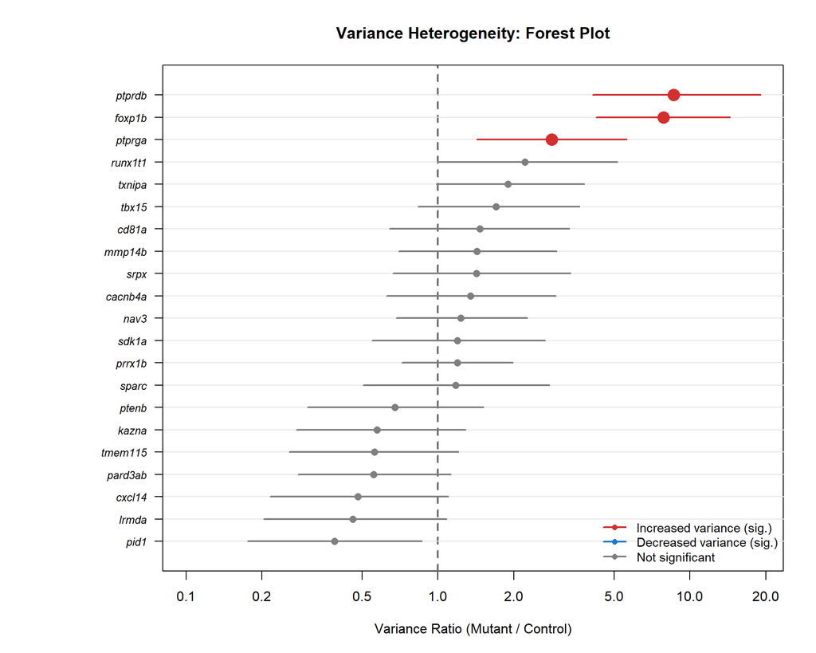

```r
par(mar = c(5, 10, 4, 2))

plot_var <- variance_df[order(variance_df$var_ratio), ]
n_genes <- nrow(plot_var)

# Calculate 95% CI for variance ratio using F distribution
plot_var$var_ci_lower <- plot_var$var_ratio / qf(0.975, plot_var$n_expt - 1, plot_var$n_ctrl - 1)
plot_var$var_ci_upper <- plot_var$var_ratio * qf(0.975, plot_var$n_ctrl - 1, plot_var$n_expt - 1)

# Colors
plot_var$color <- "gray50"
plot_var$color[plot_var$var_sig & plot_var$var_ratio > 1] <- "#D32F2F"
plot_var$color[plot_var$var_sig & plot_var$var_ratio < 1] <- "#1976D2"

# Plot
plot(NULL,
     xlim = c(0.1, max(plot_var$var_ci_upper, 15, na.rm = TRUE)),
     ylim = c(0.5, n_genes + 0.5),
     xlab = "Variance Ratio (Mutant / Control)",
     ylab = "",
     yaxt = "n",
     main = "Variance Heterogeneity: Forest Plot",
     log = "x")

abline(v = 1, lty = 2, col = "gray40", lwd = 2)
abline(h = 1:n_genes, col = "gray90", lty = 1)

for (i in 1:n_genes) {
  segments(plot_var$var_ci_lower[i], i, plot_var$var_ci_upper[i], i,
           col = plot_var$color[i], lwd = 2)
  points(plot_var$var_ratio[i], i, pch = 16, col = plot_var$color[i],
         cex = ifelse(plot_var$var_sig[i], 2, 1.2))
}

axis(2, at = 1:n_genes, labels = plot_var$gene, las = 1, cex.axis = 0.8, font = 3)

legend("bottomright",
       legend = c("Increased variance (sig.)", "Decreased variance (sig.)", "Not significant"),
       col = c("#D32F2F", "#1976D2", "gray50"),
       pch = 16, lty = 1, lwd = 2,
       bty = "n", cex = 0.9)
```

# LMM Robustness to Heteroscedasticity

For genes with significantly altered variance, we verify that LMM results are robust using alternative methods that do not assume equal variance.

```r
# Focus on genes with high variance ratios OR robust hits (stratified KS + LMM)
genes_to_check <- unique(c(
  variance_df$gene[variance_df$var_sig],
  combined_results$gene[combined_results$robust_sig]
))

robustness_results <- list()

for (gene in genes_to_check) {

  ctrl_data <- all_data[all_data$gene == gene & all_data$genotype == "control", ]
  expt_data <- all_data[all_data$gene == gene & all_data$genotype == "mutant", ]

  ctrl_data <- ctrl_data[!is.na(ctrl_data$AreaSum) & ctrl_data$AreaSum > 0 &
                         !is.na(ctrl_data$Feret) & ctrl_data$Feret > 0, ]
  expt_data <- expt_data[!is.na(expt_data$AreaSum) & expt_data$AreaSum > 0 &
                         !is.na(expt_data$Feret) & expt_data$Feret > 0, ]

  ctrl_data$genotype <- "control"
  expt_data$genotype <- "mutant"
  combined <- rbind(ctrl_data, expt_data)
  combined$genotype <- factor(combined$genotype, levels = c("control", "mutant"))
  combined$log_AreaSum <- log(combined$AreaSum)
  combined$log_Feret <- log(combined$Feret)
  combined$experiment <- factor(combined$experiment)

  n_expts <- length(unique(combined$experiment))
  if (n_expts < 2) next

  var_ratio <- variance_df$var_ratio[variance_df$gene == gene]

  res <- list(gene = gene, var_ratio = var_ratio)

  # Method 1: Standard LMM
  tryCatch({
    model_lmer <- lmer(log_Feret ~ log_AreaSum + genotype + (1 | experiment),
                       data = combined, REML = TRUE)
    coefs <- summary(model_lmer)$coefficients
    res$lmer_pct <- (exp(coefs["genotypemutant", "Estimate"]) - 1) * 100
    res$lmer_p <- coefs["genotypemutant", "Pr(>|t|)"]
  }, error = function(e) { res$lmer_pct <- NA; res$lmer_p <- NA })

  # Method 2: Heteroscedastic LMM (nlme)
  tryCatch({
    model_nlme <- lme(log_Feret ~ log_AreaSum + genotype,
                      random = ~ 1 | experiment,
                      weights = varIdent(form = ~ 1 | genotype),
                      data = combined, method = "REML")
    coefs_nlme <- summary(model_nlme)$tTable
    res$nlme_pct <- (exp(coefs_nlme["genotypemutant", "Value"]) - 1) * 100
    res$nlme_p <- coefs_nlme["genotypemutant", "p-value"]
  }, error = function(e) { res$nlme_pct <- NA; res$nlme_p <- NA })

  # Method 3: Permutation test
  tryCatch({
    model_null <- lmer(log_Feret ~ log_AreaSum + (1 | experiment), data = combined, REML = TRUE)
    combined$resid <- residuals(model_null)
    obs_diff <- mean(combined$resid[combined$genotype == "mutant"]) -
                mean(combined$resid[combined$genotype == "control"])

    n_perm <- 2000
    perm_diffs <- numeric(n_perm)
    set.seed(42)
    for (i in 1:n_perm) {
      perm_geno <- combined$genotype
      for (exp in unique(combined$experiment)) {
        idx <- which(combined$experiment == exp)
        perm_geno[idx] <- sample(perm_geno[idx])
      }
      perm_diffs[i] <- mean(combined$resid[perm_geno == "mutant"]) -
                       mean(combined$resid[perm_geno == "control"])
    }
    res$perm_pct <- (exp(obs_diff) - 1) * 100
    res$perm_p <- mean(abs(perm_diffs) >= abs(obs_diff))
  }, error = function(e) { res$perm_pct <- NA; res$perm_p <- NA })

  # Method 4: Welch t-test on residuals
  tryCatch({
    ctrl_resid <- combined$resid[combined$genotype == "control"]
    expt_resid <- combined$resid[combined$genotype == "mutant"]
    welch <- t.test(expt_resid, ctrl_resid, var.equal = FALSE)
    res$welch_pct <- (exp(diff(welch$estimate)) - 1) * 100
    res$welch_p <- welch$p.value
  }, error = function(e) { res$welch_pct <- NA; res$welch_p <- NA })

  robustness_results[[gene]] <- res
}

robustness_df <- do.call(rbind, lapply(robustness_results, as.data.frame))
rownames(robustness_df) <- NULL
```

## Robustness Comparison Table

```r
# Determine consensus
robustness_df$consensus <- apply(robustness_df, 1, function(row) {
  p_vals <- as.numeric(c(row["lmer_p"], row["nlme_p"], row["perm_p"], row["welch_p"]))
  p_vals <- p_vals[!is.na(p_vals)]
  sig <- p_vals < 0.05
  if (all(sig)) return("ALL SIG")
  if (all(!sig)) return("ALL NS")
  return("MIXED")
})

robustness_display <- data.frame(
  Gene = sapply(robustness_df$gene, function(x) format_gene_name(x, italics = TRUE)),
  Var_ratio = sprintf("%.2fx", robustness_df$var_ratio),
  LMM_p = sprintf("%.4f", robustness_df$lmer_p),
  NLME_p = ifelse(is.na(robustness_df$nlme_p), "-", sprintf("%.4f", robustness_df$nlme_p)),
  Perm_p = ifelse(is.na(robustness_df$perm_p), "-", sprintf("%.4f", robustness_df$perm_p)),
  Welch_p = ifelse(is.na(robustness_df$welch_p), "-", sprintf("%.4f", robustness_df$welch_p)),
  Consensus = robustness_df$consensus
)

kable(robustness_display,
      col.names = c("Gene", "Var Ratio", "Standard LMM", "Heterosced. LMM", "Permutation", "Welch", "Consensus"),
      caption = "LMM Robustness to Heteroscedasticity",
      align = c("l", "r", "r", "r", "r", "r", "c")) %>%
  kable_styling(bootstrap_options = c("striped", "hover", "condensed"), full_width = FALSE) %>%
  column_spec(7, bold = TRUE)
```

LMM Robustness to Heteroscedasticity

|  | Gene | Var Ratio | Standard LMM | Heterosced. LMM | Permutation | Welch | Consensus |
| --- | --- | --- | --- | --- | --- | --- | --- |
| ptprdb | *ptprdb* | 8.61x | 0.0165 | 0.0234 | 0.0095 | 0.0233 | ALL SIG |
| foxp1b | *foxp1b* | 7.86x | 0.0070 | 0.0069 | 0.0050 | 0.0081 | ALL SIG |
| ptprga | *ptprga* | 2.82x | 0.7658 | 0.7660 | 0.7635 | 0.7640 | ALL NS |
| txnipa | *txnipa* | 1.90x | 0.0000 | 0.0000 | 0.0000 | 0.0001 | ALL SIG |
| mmp14b | *mmp14b* | 1.43x | 0.0000 | 0.0000 | 0.0000 | 0.0000 | ALL SIG |

**Methods compared:**

- **Standard LMM (lme4)**: Assumes equal variance across groups
- **Heteroscedastic LMM (nlme)**: Models different variance per genotype
- **Permutation test**: Non-parametric, no distributional assumptions
- **Welch t-test**: Allows unequal variance (on size-corrected residuals)

**Interpretation:**

- **ALL SIG**: Result robust - all methods agree on significance
- **ALL NS**: Not significant by any method
- **MIXED**: Methods disagree - interpret with caution

```r
all_sig <- robustness_df[robustness_df$consensus == "ALL SIG", ]
mixed <- robustness_df[robustness_df$consensus == "MIXED", ]

if (nrow(all_sig) > 0) {
  cat("\n**Robust results (all methods agree):**\n\n")
  for (i in 1:nrow(all_sig)) {
    gene_md <- format_gene_name(all_sig$gene[i], italics = TRUE)
    cat(sprintf("- %s: LMM p=%.4f, Permutation p=%.4f\n",
                gene_md, all_sig$lmer_p[i], all_sig$perm_p[i]))
  }
}
```

**Robust results (all methods agree):**

- *ptprdb*: LMM p=0.0165, Permutation p=0.0095
- *foxp1b*: LMM p=0.0070, Permutation p=0.0050
- *txnipa*: LMM p=0.0000, Permutation p=0.0000
- *mmp14b*: LMM p=0.0000, Permutation p=0.0000

```r
if (nrow(mixed) > 0) {
  cat("\n**Potentially unreliable (methods disagree):**\n\n")
  for (i in 1:nrow(mixed)) {
    gene_md <- format_gene_name(mixed$gene[i], italics = TRUE)
    cat(sprintf("- %s: interpret with caution\n", gene_md))
  }
}

cat("\n*All robust hits (significant in both KS and LMM) show consistent results across all methods,*
*confirming that findings are not artifacts of heteroscedasticity.*\n")
```

*All robust hits (significant in both KS and LMM) show consistent results across all methods,* *confirming that findings are not artifacts of heteroscedasticity.*

# Conclusions

```r
cat("## Robust Findings\n\n")
```

## Robust Findings

```r
if (length(robust_sig_genes) > 0) {
  cat("The following genes showed significant **intercept** (uniform shift) phenotypes in both **stratified KS** (within-experiment validation) AND **LMM** (batch-corrected):\n\n")

  for (gene in sort(robust_sig_genes)) {
    gene_data <- combined_results[combined_results$gene == gene, ]
    gene_md <- format_gene_name(gene, italics = TRUE)

    pooled_note <- ""
    if (gene_data$KS_sig) pooled_note <- ", pooled KS ***"

    cat(sprintf("- **%s**: %s (%+.1f um / %+.1f%%, stratified KS adj.p = %.4f, LMM adj.p = %.4f%s)\n",
                gene_md,
                gene_data$direction_ks,
                gene_data$effect_um,
                gene_data$intercept_pct,
                gene_data$stratified_KS_p_adj,
                gene_data$intercept_p_adj,
                pooled_note))
  }
  cat("\n")
} else {
  cat("No genes were significant in both stratified KS and LMM.\n\n")
}
```

The following genes showed significant **intercept** (uniform shift) phenotypes in both **stratified KS** (within-experiment validation) AND **LMM** (batch-corrected):

- *foxp1b*: Hypertrophic (+8.8 um / +17.0%, stratified KS adj.p = 0.0194, LMM adj.p = 0.0490)
- *mmp14b*: Hypertrophic (+5.4 um / +15.8%, stratified KS adj.p = 0.0052, LMM adj.p = 0.0002, pooled KS ***)
- *txnipa*: Hypertrophic (+4.6 um / +19.9%, stratified KS adj.p = 0.0001, LMM adj.p = 0.0002)

```r
# Slope effects
if (length(slope_sig_genes) > 0) {
  cat("## Size-Dependent Effects (Slope)\n\n")
  cat("The following genes showed significant **slope** differences, indicating size-dependent phenotypes:\n\n")
  for (gene in sort(slope_sig_genes)) {
    gene_data <- lmm_results[lmm_results$gene == gene, ]
    gene_md <- format_gene_name(gene, italics = TRUE)
    direction <- ifelse(gene_data$slope_effect > 0, "steeper", "shallower")
    cat(sprintf("- **%s**: %s slope (%+.4f, adj.p = %.4f)\n",
                gene_md, direction, gene_data$slope_effect, gene_data$slope_p_adj))
  }
  cat("\n*A steeper slope means the hypertrophic/hyperplastic phenotype is more pronounced in larger fish.*\n\n")
}
```

## Size-Dependent Effects (Slope)

The following genes showed significant **slope** differences, indicating size-dependent phenotypes:

- *tbx15*: steeper slope (+0.1070, adj.p = 0.0255)
- *txnipa*: shallower slope (-0.0505, adj.p = 0.0255)

*A steeper slope means the hypertrophic/hyperplastic phenotype is more pronounced in larger fish.*

```r
cat("## Single-Experiment Genes (*aspa*, *lamb2*)\n\n")
```

## Single-Experiment Genes (*aspa*, *lamb2*)

```r
if (exists("single_results") && !is.null(single_results) && nrow(single_results) > 0) {
  for (i in 1:nrow(single_results)) {
    gene_md <- format_gene_name(single_results$gene[i], italics = TRUE)
    ks_sig_text <- ifelse(single_results$KS_sig[i], "*", "")
    lm_sig_text <- ifelse(single_results$LM_sig[i], "*", "")
    cat(sprintf("- **%s**: %s (KS: %+.1f um, p=%.3f%s | LM: %+.1f%%, p=%.3f%s)\n",
                gene_md,
                single_results$direction[i],
                single_results$KS_effect_um[i],
                single_results$KS_p[i],
                ks_sig_text,
                single_results$LM_effect_pct[i],
                single_results$LM_p[i],
                lm_sig_text))
  }
  cat("\n*Note: These genes had only one experiment and could not be batch-corrected.*\n\n")
}
```

- *aspa*: Hypertrophic (KS: +6.0 um, p=0.003* | LM: +16.7%, p=0.021*)
- *lamb2*: Hypertrophic (KS: -3.3 um, p=0.359 | LM: +15.1%, p=0.321)

*Note: These genes had only one experiment and could not be batch-corrected.*

```r
cat("## Methodological Notes\n\n")
```

## Methodological Notes

```r
cat("1. KS tests compare full distributions; LMM tests mean differences (intercept and slope)\n")
```

1. KS tests compare full distributions; LMM tests mean differences (intercept and slope)

```r
cat("2. LMM includes experiment as random effect to account for batch variation\n")
```

2. LMM includes experiment as random effect to account for batch variation

```r
cat("3. **Stratified KS** tests run within each experiment and combined via Fisher's method - this validates that effects are consistent within experiments (not batch artifacts)\n")
```

3. **Stratified KS** tests run within each experiment and combined via Fisher’s method - this validates that effects are consistent within experiments (not batch artifacts)

```r
cat("4. Benjamini-Hochberg correction applied separately to intercept and slope p-values across ", nrow(lmm_results), " multi-experiment genes\n", sep = "")
```

4. Benjamini-Hochberg correction applied separately to intercept and slope p-values across 21 multi-experiment genes

```r
cat("5. Genes *aspa* and *lamb2* (single experiment) analysed separately without batch correction\n")
```

5. Genes *aspa* and *lamb2* (single experiment) analysed separately without batch correction

```r
cat("6. Variance heterogeneity analysis identifies genes with altered distributional spread\n")
```

6. Variance heterogeneity analysis identifies genes with altered distributional spread

```r
cat("7. LMM robustness verified using heteroscedastic LMM, permutation tests, and Welch's t-test\n")
```

7. LMM robustness verified using heteroscedastic LMM, permutation tests, and Welch’s t-test

```r
cat("8. **Primary criterion for robust hits:** Significant in both stratified KS AND LMM. Pooled KS alone may be inflated by batch effects.\n")
```

8. **Primary criterion for robust hits:** Significant in both stratified KS AND LMM. Pooled KS alone may be inflated by batch effects.

# Export Results

```r
# Create output directory path (same as data file location)
output_dir <- dirname(data_file)
if (output_dir == ".") output_dir <- getwd()

# Save combined results (main analysis)
write.csv(combined_results, file.path(output_dir, "Combined_KS_LMM_results.csv"), row.names = FALSE)
cat("Combined results saved to:", file.path(output_dir, "Combined_KS_LMM_results.csv"), "\n")
```

```
## Combined results saved to: C:/Users/james/Desktop/2025_adipose_morphology_screen_elife/doubleCheck_screen_analysis/2025-04-10_ks_tests_expt_controls/completeSet_summaryStats_v2/Combined_KS_LMM_results.csv
```

```r
# Save KS results
write.csv(ks_results, file.path(output_dir, "KS_test_results.csv"), row.names = FALSE)

# Save LMM results
write.csv(lmm_results, file.path(output_dir, "LMM_results.csv"), row.names = FALSE)

# Save variance analysis results
if (exists("variance_df") && !is.null(variance_df) && nrow(variance_df) > 0) {
  write.csv(variance_df, file.path(output_dir, "Variance_heterogeneity_results.csv"), row.names = FALSE)
  cat("Variance analysis saved to: Variance_heterogeneity_results.csv\n")
}
```

```
## Variance analysis saved to: Variance_heterogeneity_results.csv
```

```r
# Save stratified KS results
if (exists("stratified_df") && !is.null(stratified_df) && nrow(stratified_df) > 0) {
  write.csv(stratified_df, file.path(output_dir, "Stratified_KS_results.csv"), row.names = FALSE)
  cat("Stratified KS analysis saved to: Stratified_KS_results.csv\n")
}
```

```
## Stratified KS analysis saved to: Stratified_KS_results.csv
```

```r
# Save robustness analysis results
if (exists("robustness_df") && !is.null(robustness_df) && nrow(robustness_df) > 0) {
  write.csv(robustness_df, file.path(output_dir, "LMM_robustness_results.csv"), row.names = FALSE)
  cat("Robustness analysis saved to: LMM_robustness_results.csv\n")
}
```

```
## Robustness analysis saved to: LMM_robustness_results.csv
```

```r
# Save single-experiment results
if (exists("single_results") && !is.null(single_results) && nrow(single_results) > 0) {
  write.csv(single_results, file.path(output_dir, "Single_experiment_results.csv"), row.names = FALSE)
  cat("Single-experiment results saved to: Single_experiment_results.csv\n")
}
```

```
## Single-experiment results saved to: Single_experiment_results.csv
```

*Analysis completed: 2026-01-29 15:32:02.434836*